# What happens to resting BTC orders on HyperLiquid when price moves

#### 2.2 The displayed edge trades far less than it shows, as does any level price approaches

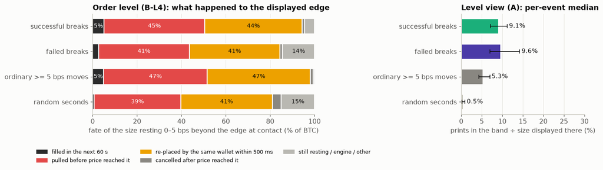

```
pooled level ratio: successes 21.6% [13.8–32.2], ordinary moves 14.3% [11.3–17.6]; about three quarters of the prints in the band hit orders placed after contact.
```

```python
FB, LR = Q2["F2b_fate_of_edge_depth"], Q2["F2c_level_ratio"]
groups = [("SUCCESS", "successful breaks"), ("FAILED", "failed breaks"),
          ("ORDINARY", "ordinary >= 5 bps moves"), ("RANDOM", "random seconds")]
segs = [("filled", "filled in the next 60 s", C["filled"]),
        ("pull", "pulled before price reached it", C["pulled"]),
        ("rq", "re-placed by the same wallet within 500 ms", C["requoted"]),
        ("after", "cancelled after price reached it", C["muted"]),
        ("rest", "still resting / engine / other", C["added"])]
fig, axs = plt.subplots(1, 2, figsize=(13, 3.6), gridspec_kw={"width_ratios": [1.8, 1]})
ax = axs[0]
for yi, (k, lab) in enumerate(groups):
    vals = {"filled": FB["W60_filled_all_share_of_size"][k]["ratio"],
            "pull": FB["W60_cancel_before_split_share_of_size"]["pull"][k]["ratio"],
            "rq": FB["W60_cancel_before_split_share_of_size"]["rq"][k]["ratio"],
            "after": FB["W60_cancel_after_all_share_of_size"][k]["ratio"]}
    vals["rest"] = max(0.0, 1 - sum(vals.values()))
    left = 0.0
    for s_, _, col in segs:
        v = vals[s_]
        ax.barh(yi, v * 100, left=left, color=col, edgecolor=C["surface"], lw=1.5, height=0.62)
        if v >= 0.045:
            ax.text(left + v * 50, yi, f"{100 * v:.0f}%", ha="center", va="center", fontsize=9,
                    color="white" if col in (C["filled"], C["pulled"]) else C["ink"])
        left += v * 100
ax.set_yticks(range(4), [g[1] for g in groups])
ax.invert_yaxis()
ax.set_xlim(0, 100)
ax.grid(axis="y", visible=False)
ax.set_xlabel("fate of the size resting 0–5 bps beyond the edge at contact (% of BTC)")
ax.legend(handles=[Patch(color=c, label=n) for _, n, c in segs], ncol=3, fontsize=8.5, loc="upper center",
          bbox_to_anchor=(0.5, -0.3))
ax.set_title("Order level (B-L4): what happened to the displayed edge")
ci_bars(axs[1], [g[1] for g in groups], [est(LR["per_event"][k]) for k, _ in groups],
        [C["success"], C["failed"], C["ordinary"], C["random"]], xlim=(0, 30),
        xlabel="prints in the band ÷ size displayed there (%)", label_fmt="{:.1f}%")
axs[1].set_title("Level view (A): per-event median")
plt.show()
print(f"pooled level ratio: successes {fmt(est(LR['pooled']['SUCCESS']), d=1)}, ordinary moves "
      f"{fmt(est(LR['pooled']['ORDINARY']), d=1)}; about three quarters of the prints in the band hit orders "
      "placed after contact.")
```

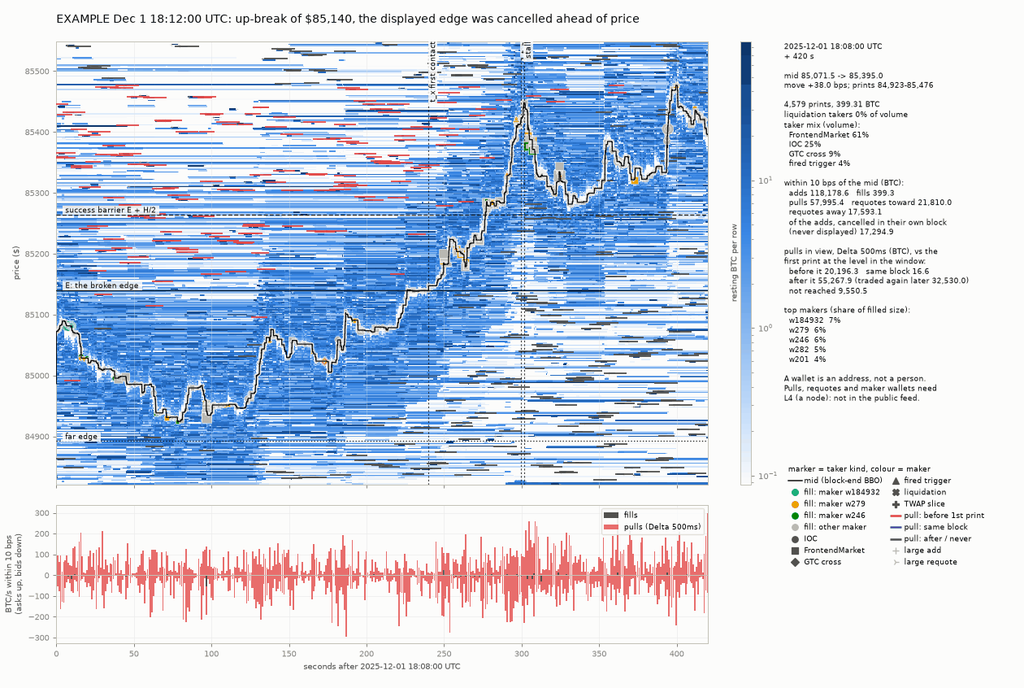

**What to look at:** the edge rows above $85,140 are dark at contact, then turn into red dashes as price approaches: 89 BTC displayed, 98% cancelled before price came, 2% filled. Price traded through the whole band, yet only **3.2 BTC printed in it** (4% of the display).

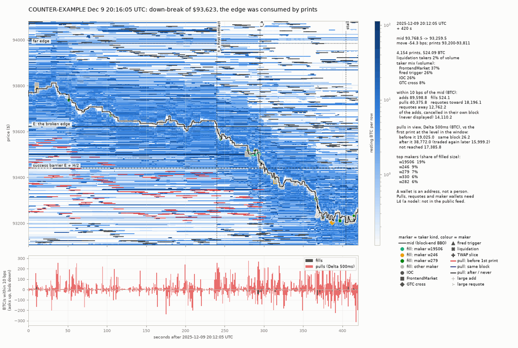

**What to look at:** a small display (14 BTC) that was really there: 38% of it filled, 40% of the display printed, 94% of those prints against orders resting at contact. Price ran 45 bps.

**Observation.** Of the size resting 0–5 bps beyond the edge at contact, on successful breaks, 5.2% [3.4–7.4] was filled in the next 60 s and 89% was cancelled before price reached it (about half pulled, half re-placed by the same wallet within 500 ms, mostly further away). Level view: break-direction prints in the band in that minute ÷ size displayed there = per-event median 9.1% [7.1–11.2], pooled 21.6% [13.8–32.2]. Ordinary >= 5 bps moves look the same: 5.0% filled, 93% cancelled first, level ratio 5.3% (pooled 14.3%).

**Interpretation.** Expect roughly a tenth of the size displayed just past a range edge to trade there in the next minute (per-event median; about a fifth pooled). **It is generic churn at any approached level, not a range-edge property.**

**Class.** Level ratio: **A**. Order fates and pull/requote: **B-L4**.

```python
q2_card("f2_success_cancelled_ahead", "**What to look at:** the edge rows above $85,140 are dark at contact, "
        "then turn into red dashes as price approaches: 89 BTC displayed, 98% cancelled before price came, "
        "2% filled. Price traded through the whole band, yet only **3.2 BTC printed in it** (4% of the display).",
        title="EXAMPLE Dec 1 18:12:00 UTC: up-break of $85,140, the displayed edge was cancelled ahead of price")
q2_card("f2_counter_consumed", "**What to look at:** a small display (14 BTC) that was really there: 38% of "
        "it filled, 40% of the display printed, 94% of those prints against orders resting at contact. "
        "Price ran 45 bps.",
        title="COUNTER-EXAMPLE Dec 9 20:16:05 UTC: down-break of $93,623, the edge was consumed by prints")
note("Of the size resting 0–5 bps beyond the edge at contact, on successful breaks, 5.2% [3.4–7.4] was "
     "filled in the next 60 s and 89% was cancelled before price reached it (about half pulled, half "
     "re-placed by the same wallet within 500 ms, mostly further away). Level view: break-direction prints "
     "in the band in that minute ÷ size displayed there = per-event median 9.1% [7.1–11.2], pooled 21.6% "
     "[13.8–32.2]. Ordinary >= 5 bps moves look the same: 5.0% filled, 93% cancelled first, level ratio "
     "5.3% (pooled 14.3%).",
     "Expect roughly a tenth of the size displayed just past a range edge to trade there in the next minute "
     "(per-event median; about a fifth pooled). **It is generic churn at any approached level, not a "
     "range-edge property.**",
     "Level ratio: **A**. Order fates and pull/requote: **B-L4**.")
```

#### 2.3 The side behind price thinned after contact, as it does after any move

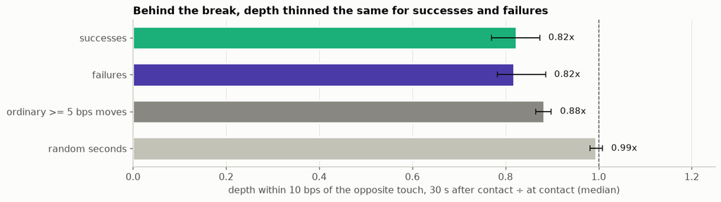

```
success minus failure: +0.01 log2 [-0.13, +0.13]
```

```python
F3 = Q2["F3_opposite_refill"]
rows = [("successes", F3["oT_0_10_log2ratio_p30"]["SUCCESS"], C["success"]),
        ("failures", F3["oT_0_10_log2ratio_p30"]["FAILED"], C["failed"]),
        ("ordinary >= 5 bps moves", F3["oT_0_10_log2ratio_p30_controls"]["ORDINARY"], C["ordinary"]),
        ("random seconds", F3["oT_0_10_log2ratio_p30_controls"]["RANDOM"], C["random"])]
fig, ax = plt.subplots(figsize=(11, 3.0))
tri = [tuple(2 ** np.array(est(d))) for _, d, _ in rows]
ci_bars(ax, [r[0] for r in rows], tri, [r[2] for r in rows], scale=1, label_fmt="{:.2f}x", xlim=(0, 1.25),
        xlabel="depth within 10 bps of the opposite touch, 30 s after contact ÷ at contact (median)", ref=1.0)
ax.set_title("Behind the break, depth thinned the same for successes and failures")
plt.show()
dd = F3["diff_S_minus_F_oT_p30"]
print(f"success minus failure: {dd['diff']:+.2f} log2 [{dd['ci95'][0]:+.2f}, {dd['ci95'][1]:+.2f}]")
```

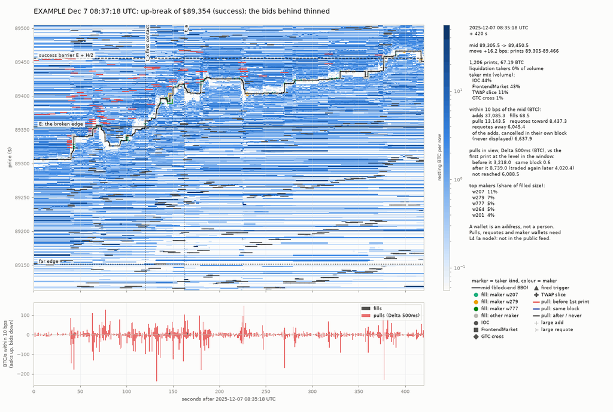

**What to look at:** the bid side below the rising mid: 222 BTC at contact, 173 BTC 30 s later, 199 BTC later on. The same thinning appears on failures (Dec 1 19:30:01, not shown).

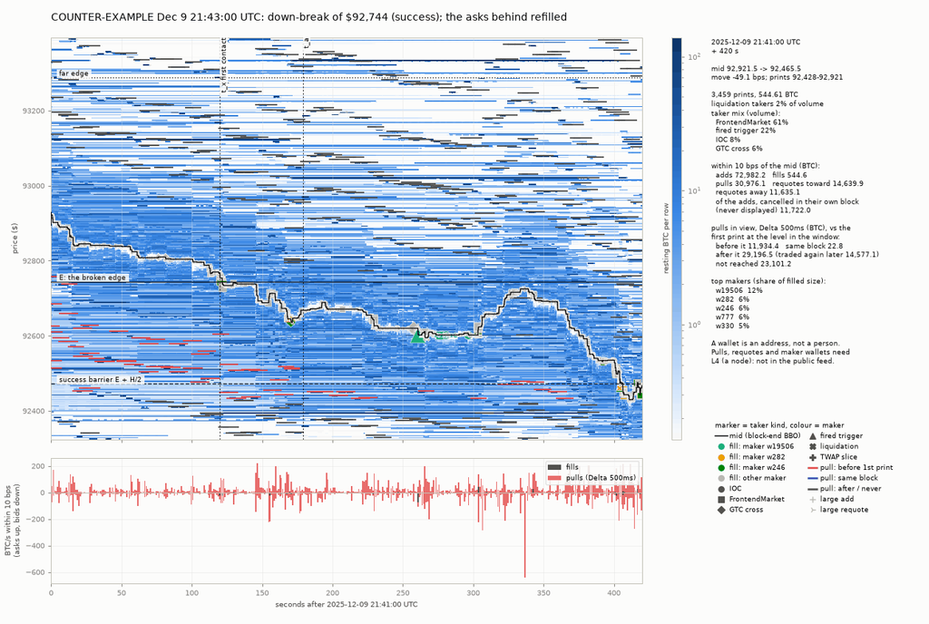

**What to look at:** the asks behind the falling price *refilled* (195 → 238 BTC). It happens, but it did not mark successes.

**Observation.** Depth within 10 bps of the opposite touch, 30 s after contact vs at contact: success 0.82x, failure 0.82x (difference +0.01 log2 [-0.13, +0.13]), ordinary moves 0.88x, random seconds 0.99x.

**Interpretation.** There was no 'bids stepping in behind the break' pattern that marked successes. The burst of opposite-side adds at contact came with every kind of contact; it is consistent with mechanical same-side refill (a ~89 ms median in the literature), which a trader sees as quote flicker.

**Class.** **A**.

```python
q2_card("f3_success_thins", "**What to look at:** the bid side below the rising mid: 222 BTC at contact, "
        "173 BTC 30 s later, 199 BTC later on. The same thinning appears on failures (Dec 1 19:30:01, not shown).",
        title="EXAMPLE Dec 7 08:37:18 UTC: up-break of $89,354 (success); the bids behind thinned")
q2_card("f3_counter_refill", "**What to look at:** the asks behind the falling price *refilled* (195 → 238 "
        "BTC). It happens, but it did not mark successes.",
        title="COUNTER-EXAMPLE Dec 9 21:43:00 UTC: down-break of $92,744 (success); the asks behind refilled")
note("Depth within 10 bps of the opposite touch, 30 s after contact vs at contact: success 0.82x, failure "
     "0.82x (difference +0.01 log2 [-0.13, +0.13]), ordinary moves 0.88x, random seconds 0.99x.",
     "There was no 'bids stepping in behind the break' pattern that marked successes. The burst of "
     "opposite-side adds at contact came with every kind of contact; it is consistent with mechanical "
     "same-side refill (a ~89 ms median in the literature), which a trader sees as quote flicker.",
     "**A**.")
```

#### 2.4 Fired stops were a large, lumpy part of break volume, and resting stops did not predict the outcome

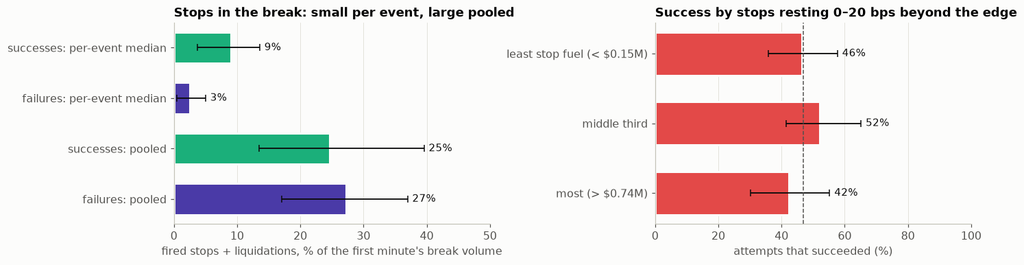

```
stops resting 0–20 bps beyond the edge at contact: success $0.33M vs failure $0.49M (difference -$0.16M [-0.42, +0.20])
```

```python
F4 = Q2["F4_stops"]
fig, axs = plt.subplots(1, 2, figsize=(13, 3.4))
lab = ["successes: per-event median", "failures: per-event median", "successes: pooled", "failures: pooled"]
tri = [est(F4["b60_trigliq_share_per_event"]["SUCCESS"]), est(F4["b60_trigliq_share_per_event"]["FAILED"]),
       est(F4["b60_trigliq_share_pooled"]["SUCCESS"]), est(F4["b60_trigliq_share_pooled"]["FAILED"])]
ci_bars(axs[0], lab, tri, [C["success"], C["failed"], C["success"], C["failed"]], xlim=(0, 50),
        xlabel="fired stops + liquidations, % of the first minute's break volume")
axs[0].set_title("Stops in the break: small per event, large pooled")
TS = F4["success_by_stopfuel_tercile"]
cut = TS["cuts_musd"]
ci_bars(axs[1], [f"least stop fuel (< ${cut[0] / 1e6:.2f}M)", "middle third", f"most (> ${cut[1] / 1e6:.2f}M)"],
        [est(TS[f"T{i}"]) for i in (1, 2, 3)], C["pulled"], xlim=(0, 100), ref=100 * 100 / 213,
        xlabel="attempts that succeeded (%)")
axs[1].set_title("Success by stops resting 0–20 bps beyond the edge")
plt.show()
dd = F4["diff_S_minus_F_trigc_0_20_usd"]
print(f"stops resting 0–20 bps beyond the edge at contact: success ${est(F4['trigc_0_20_usd']['SUCCESS'])[0] / 1e6:.2f}M "
      f"vs failure ${est(F4['trigc_0_20_usd']['FAILED'])[0] / 1e6:.2f}M (difference {'-' if dd['diff'] < 0 else '+'}"
      f"${abs(dd['diff']) / 1e6:.2f}M [{dd['ci95'][0] / 1e6:+.2f}, {dd['ci95'][1] / 1e6:+.2f}])")
```

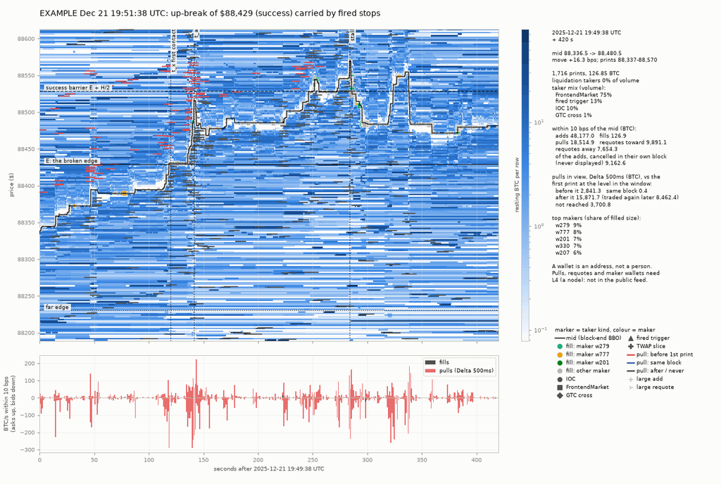

**What to look at:** the triangles right after contact: 9.1 of the first minute's 12.6 BTC were fired stops.

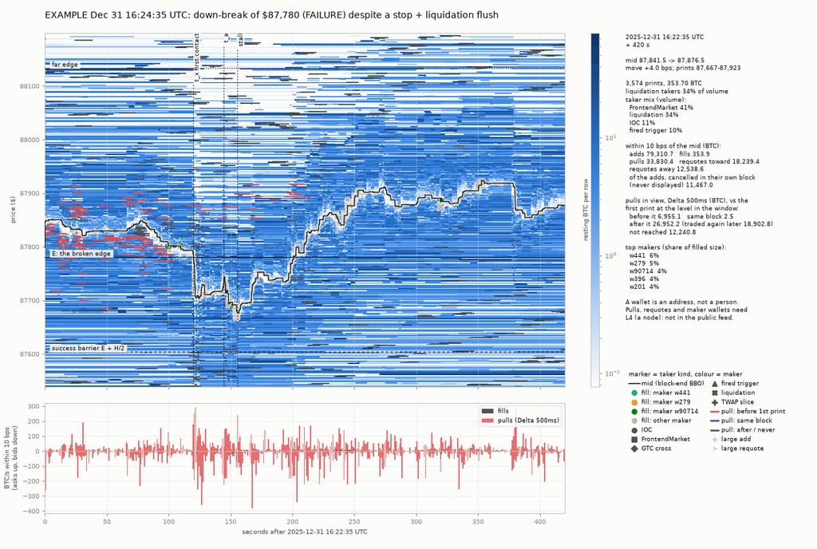

**What to look at:** a large flush of stops (35 BTC) and liquidations (67 BTC) = 102 of 135 BTC; price stalls 12 bps below E and closes back inside. The largest flushes were failures.

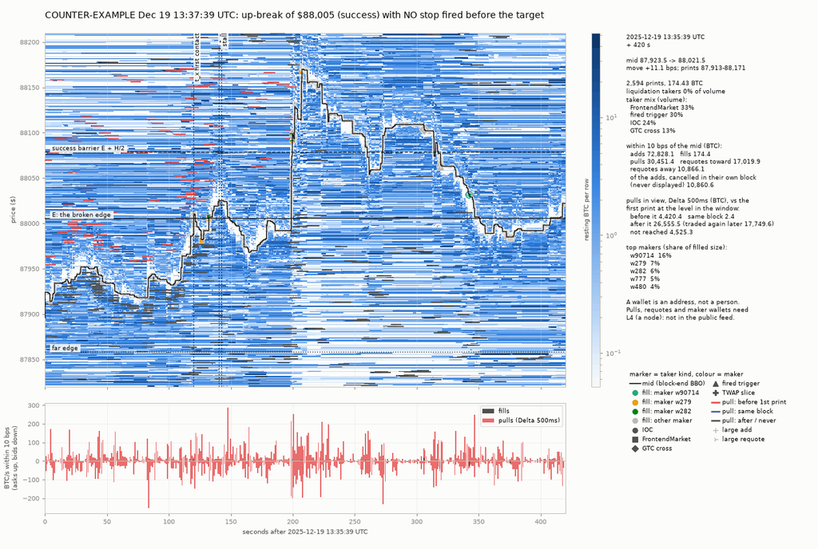

**What to look at:** no triangle before price reaches the barrier, although $2.4M of stops rested just above; they fired only afterwards.

**Observation.** Fired stops + liquidations as a share of the first minute's break volume: per-event median 9.0% [3.7–13.6] on successes vs 2.5% [0.4–5.0] on failures; pooled over events 24.7% vs 27.3% (the largest flushes were failures). Stops resting 0–20 bps beyond the edge at contact: $0.33M vs $0.49M (difference -$0.16M [-0.42, +0.20]); success rate by stop-fuel tercile 46% / 52% / 42%.

**Interpretation.** Stops that fire are largely a *consequence* of how far price goes. The stop fuel resting beyond the edge at contact did not tell the outcome. Whether it predicts follow-through is the open registered question H19/E2.

**Class.** **B-L4** (taker kind and untriggered stops). A known address's stops: **B-addr**.

```python
q2_card("f4_stop_cascade_success", "**What to look at:** the triangles right after contact: 9.1 of the first "
        "minute's 12.6 BTC were fired stops.",
        title="EXAMPLE Dec 21 19:51:38 UTC: up-break of $88,429 (success) carried by fired stops")
q2_card("f4_stops_fired_failed", "**What to look at:** a large flush of stops (35 BTC) and liquidations (67 BTC) "
        "= 102 of 135 BTC; price stalls 12 bps below E and closes back inside. The largest flushes were failures.",
        title="EXAMPLE Dec 31 16:24:35 UTC: down-break of $87,780 (FAILURE) despite a stop + liquidation flush")
q2_card("f4_counter_no_fires_to_barrier", "**What to look at:** no triangle before price reaches the barrier, "
        "although $2.4M of stops rested just above; they fired only afterwards.",
        title="COUNTER-EXAMPLE Dec 19 13:37:39 UTC: up-break of $88,005 (success) with NO stop fired before the target")
note("Fired stops + liquidations as a share of the first minute's break volume: per-event median 9.0% "
     "[3.7–13.6] on successes vs 2.5% [0.4–5.0] on failures; pooled over events 24.7% vs 27.3% (the largest "
     "flushes were failures). Stops resting 0–20 bps beyond the edge at contact: $0.33M vs $0.49M "
     "(difference -$0.16M [-0.42, +0.20]); success rate by stop-fuel tercile 46% / 52% / 42%.",
     "Stops that fire are largely a *consequence* of how far price goes. The stop fuel resting beyond the "
     "edge at contact did not tell the outcome. Whether it predicts follow-through is the open registered "
     "question H19/E2.",
     "**B-L4** (taker kind and untriggered stops). A known address's stops: **B-addr**.")
```

#### 2.5 At the first stall after a break, the book looked like the book at any local extreme

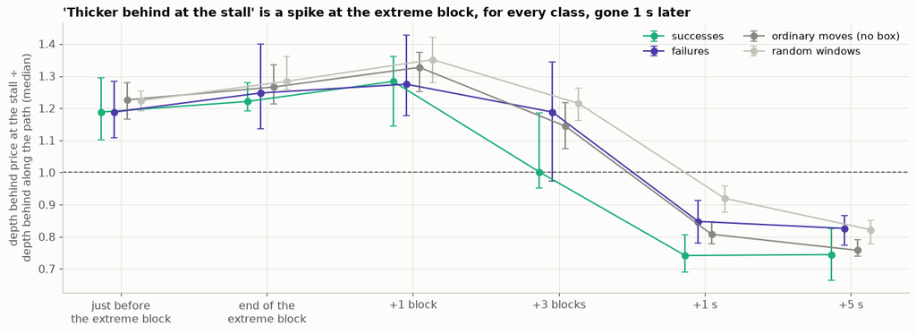

```python
BT = Q2["F5_stall"]["baseline_and_timing"]
tags = [("stB", "just before\nthe extreme block"), ("stA", "end of the\nextreme block"), ("st1b", "+1 block"),
        ("st3b", "+3 blocks"), ("st1s", "+1 s"), ("st5s", "+5 s")]
series = [("SUCCESS", "successes", C["success"]), ("FAILED", "failures", C["failed"]),
          ("ORDINARY", "ordinary moves (no box)", C["ordinary"]), ("RANDOM", "random windows", C["random"])]
fig, ax = plt.subplots(figsize=(12, 4.3))
x = np.arange(len(tags))
for j, (k, lab, col) in enumerate(series):
    tri = np.array([2 ** np.array(est(BT[f"log2_behind_{t}_over_path"][k])) for t, _ in tags])
    dx = (j - 1.5) * 0.09
    ax.errorbar(x + dx, tri[:, 0], yerr=[tri[:, 0] - tri[:, 1], tri[:, 2] - tri[:, 0]], fmt="o-", ms=6, lw=1.4,
                color=col, ecolor=col, capsize=3, label=lab)
ax.axhline(1, color=C["ink2"], lw=1, ls="--")
ax.set_xticks(x, [t[1] for t in tags])
ax.set_ylabel("depth behind price at the stall ÷\ndepth behind along the path (median)")
ax.legend(loc="upper right", ncol=2)
ax.set_title("'Thicker behind at the stall' is a spike at the extreme block, for every class, gone 1 s later")
plt.show()
```

> **What changed after the skeptic review.** A first version read the thicker book behind price at the stall as *makers re-quoting behind a paused price* (support forming behind a breakout). That reading was **withdrawn**: the same ratio appears after ordinary moves (1.27×) and in random windows (1.28×), because of **how an extreme is picked**. In 91% of stalls the extreme was set by the block in which the quote behind price stepped into a spread wider than one tick; one second later, depth behind was 0.74× the path level.

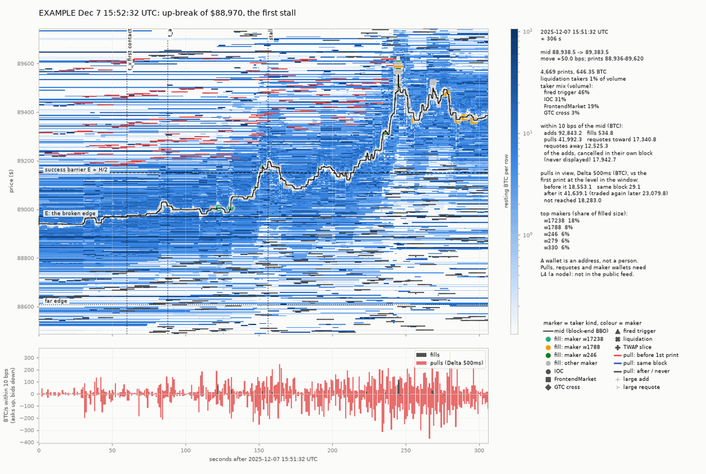

**What to look at:** at the stall the spread is 14 ticks wide, then the bid steps in: depth behind goes 188 → 172 → **41 BTC** one second later.

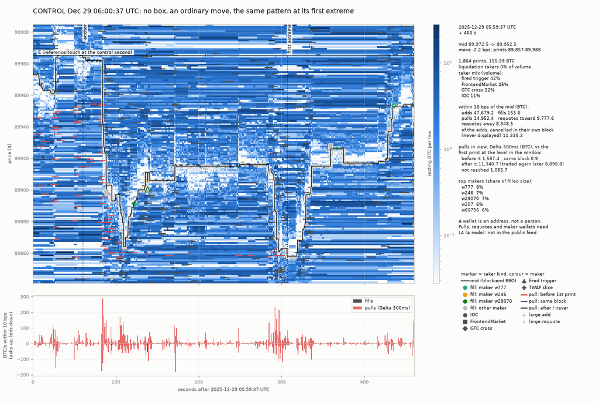

**What to look at:** no range at all, an ordinary down move, and the same picture at its first extreme.

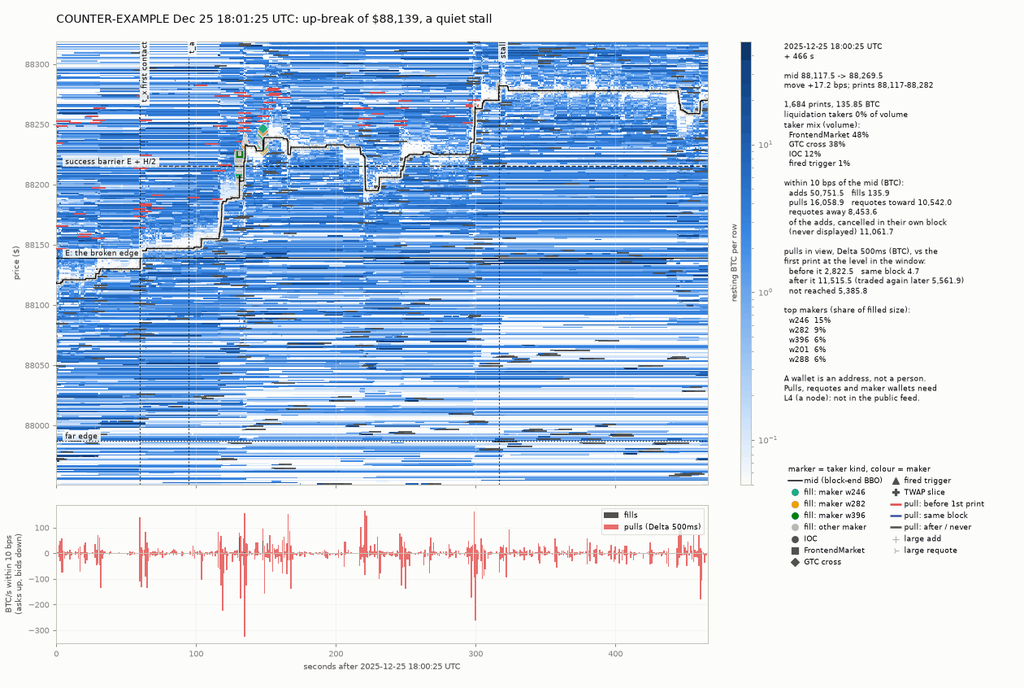

**What to look at:** a quiet stall with no burst before it and no excess depth behind.

**Observation.** Depth behind price at the first stall vs along the path: success 1.22x, ordinary moves (same rule) 1.27x, random windows 1.28x. In 91% of stalls the extreme was set by the block in which the quote behind price stepped into a spread wider than 1 tick; 1 s later depth behind was 0.74x the path level. Depth ahead was ordinary (0.96x).

**Interpretation.** Price did not visibly stop at a wall ahead, and no breakout-specific support formed behind it. The 'thicker behind' is produced by how an extreme is picked.

**Class.** Depth: **A**; the stall location: **C**.

```python
q2_card("f5_stall_after_burst_2", "**What to look at:** at the stall the spread is 14 ticks wide, then the bid "
        "steps in: depth behind goes 188 → 172 → **41 BTC** one second later.",
        title="EXAMPLE Dec 7 15:52:32 UTC: up-break of $88,970, the first stall")
q2_card("f5_control_ordinary", "**What to look at:** no range at all, an ordinary down move, and the same "
        "picture at its first extreme.",
        title="CONTROL Dec 29 06:00:37 UTC: no box, an ordinary move, the same pattern at its first extreme")
q2_card("f5_counter_quiet_stall", "**What to look at:** a quiet stall with no burst before it and no excess "
        "depth behind.",
        title="COUNTER-EXAMPLE Dec 25 18:01:25 UTC: up-break of $88,139, a quiet stall")
note("Depth behind price at the first stall vs along the path: success 1.22x, ordinary moves (same rule) "
     "1.27x, random windows 1.28x. In 91% of stalls the extreme was set by the block in which the quote "
     "behind price stepped into a spread wider than 1 tick; 1 s later depth behind was 0.74x the path level. "
     "Depth ahead was ordinary (0.96x).",
     "Price did not visibly stop at a wall ahead, and no breakout-specific support formed behind it. The "
     "'thicker behind' is produced by how an extreme is picked.",
     "Depth: **A**; the stall location: **C**.")
```

### Q4: Absorption and large displayed orders ("walls")

**Scope.** **265 absorption episodes on 14 odd days**: 15 s windows with at least **$6.07M** of net one-sided taker notional (the pooled 99th percentile) and price progress in the bottom decile given that aggression and prior volatility (median $8.8M; price moved a median −2.6 bps *against* the aggressors; Dec 13 and Dec 27 had none). **301,221 "walls" on 16 odd days**: single orders at the 99.9th size percentile for their distance (e.g. ≥ 8.66 BTC within 5 bps of the touch).

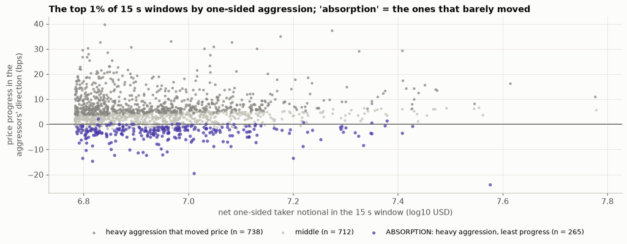

```python
QE = pd.read_parquet(INTERIM / "q4_data/episodes.parquet")
for d in QE.day.unique():
    odd_day(d)
fig, ax = plt.subplots(figsize=(11.5, 4.4))
for k, lab, col, z in (("moved", "heavy aggression that moved price", C["ordinary"], 2),
                       ("middle", "middle", C["random"], 1),
                       ("absorb", "ABSORPTION: heavy aggression, least progress", C["failed"], 3)):
    g = QE[QE.cls == k]
    ax.scatter(np.log10(g.I), g.P, s=13 if k != "absorb" else 18, color=col, alpha=0.75, lw=0, zorder=z,
               label=f"{lab} (n = {len(g)})")
ax.axhline(0, color=C["ink2"], lw=1)
ax.set_xlabel("net one-sided taker notional in the 15 s window (log10 USD)")
ax.set_ylabel("price progress in the\naggressors' direction (bps)")
ax.legend(loc="upper center", bbox_to_anchor=(0.5, -0.17), ncol=3, fontsize=9)
ax.set_title("The top 1% of 15 s windows by one-sided aggression; 'absorption' = the ones that barely moved")
plt.show()
```

#### 4.1 The price level that took the aggression was almost always used up

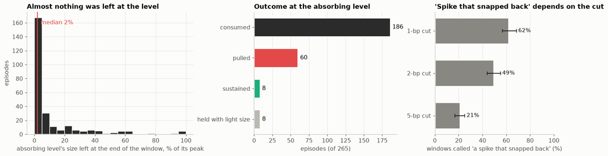

```python
AB = pd.read_parquet(INTERIM / "q4_data/absorb_labelled.parquet")
for d in AB.day.unique():
    odd_day(d)
resid = (AB.s_end / AB.s_max).clip(0, 1) * 100
fig, axs = plt.subplots(1, 3, figsize=(14, 3.8), gridspec_kw={"width_ratios": [1.4, 1.2, 1]})
ax = axs[0]
ax.hist(resid, bins=np.arange(0, 101, 5), color=C["filled"], edgecolor=C["surface"])
ax.axvline(resid.median(), color=C["pulled"], lw=1.5)
ax.text(resid.median() + 2, ax.get_ylim()[1] * 0.9, f"median {resid.median():.0f}%", color=C["pulled"])
ax.set_xlabel("absorbing level's size left at the end of the window, % of its peak")
ax.set_ylabel("episodes")
ax.set_title("Almost nothing was left at the level")
arm = AB.arm.value_counts()
lab = [("VAN_consumed", "consumed"), ("VAN_pulled", "pulled"), ("SUST", "sustained"), ("HELD_light", "held with light size")]
ax = axs[1]
ax.barh(range(4), [arm.get(k, 0) for k, _ in lab], color=[C["filled"], C["pulled"], C["success"], C["added"]],
        edgecolor=C["surface"], lw=2, height=0.62)
for i, (k, _) in enumerate(lab):
    ax.text(arm.get(k, 0) + 3, i, f"{arm.get(k, 0)}", va="center")
ax.set_yticks(range(4), [l for _, l in lab])
ax.invert_yaxis()
ax.grid(axis="y", visible=False)
ax.set_xlabel(f"episodes (of {len(AB)})")
ax.set_title("Outcome at the absorbing level")
ax = axs[2]
PT = Q4["revision"]["path_type_sensitivity"]["cut_bps"]
cuts = [c for c in ("1", "2", "5") if c in PT]
ci_bars(ax, [f"{c}-bp cut" for c in cuts], [est(PT[c]["spike_revert"]["share"]) for c in cuts], C["muted"],
        xlim=(0, 100), xlabel="windows called 'a spike that snapped back' (%)")
ax.set_title("'Spike that snapped back' depends on the cut")
plt.show()
```

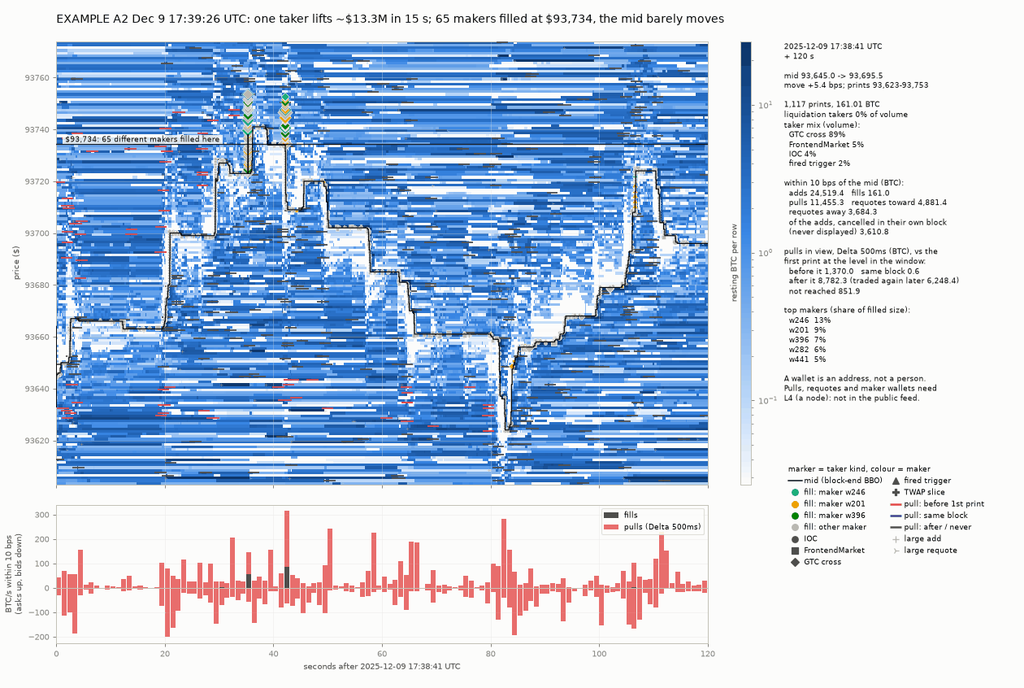

**What to look at:** the two columns of diamonds (one taker's crossing GTC orders) around the $93,734 line while the black mid hardly moves: the asks re-form within the block, again and again, from many makers. Not one order holding.

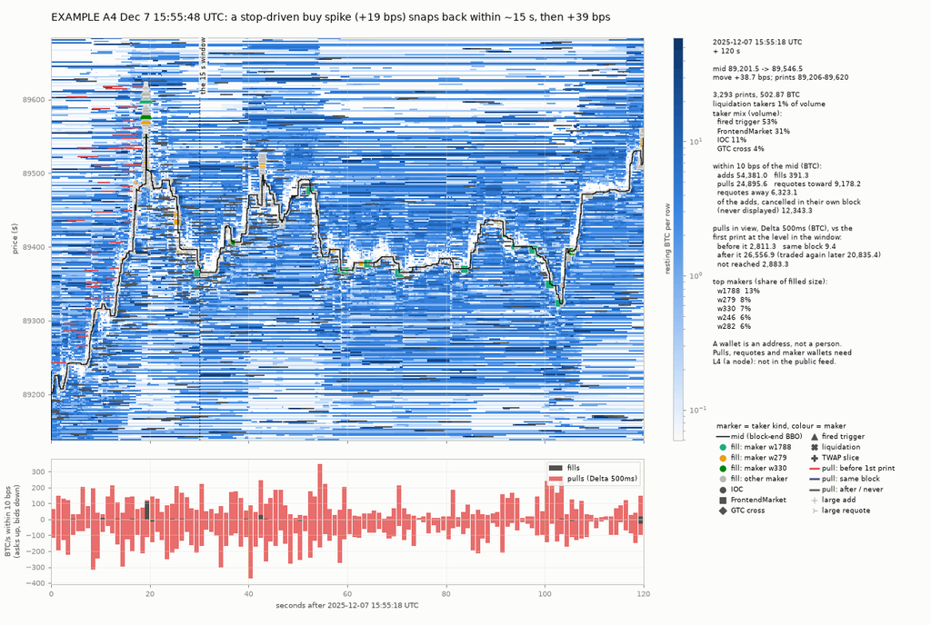

**What to look at:** the triangles (fired stops) push the mid up, it falls back inside the 15 s window (so the window counts as 'absorption'), and then price rises 39 bps anyway.

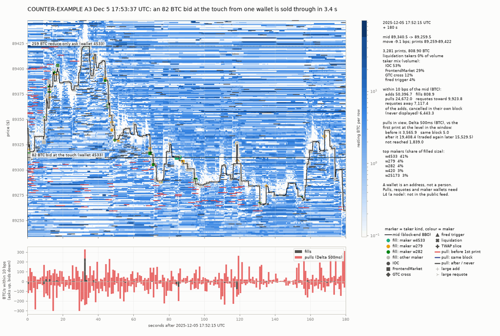

**What to look at:** the dark row at $89,312 is one wallet's 82 BTC bid; sellers go through it in 3.4 s and keep selling. One large order did not hold the level.

**Observation.** At the end of the window a median 2% of the absorbing level's peak size was still resting (IQR 0–10%): 186 consumed, 60 pulled, 8 sustained, 8 held with light size (of 265). How many windows were 'a spike that snapped back' depends on the cut, because the typical excursion is small (median 1.8 bps): 62% at a 1-bp cut, 49% at 2, 21% at 5.

**Interpretation.** Heavy aggression that fails to move price reliably finds a level that gets **consumed**, not a wall that stays. Where the mid stayed pinned, it was usually many makers re-forming the book within the block, not one order holding.

**Class.** The window (tape aggression + mid): **A**. The churn at the level: **B-L4**.

```python
render_card(T("2025-12-09 17:38:41"), T("2025-12-09 17:40:41"),
            title="EXAMPLE A2 Dec 9 17:39:26 UTC: one taker lifts ~$13.3M in 15 s; 65 makers filled at $93,734, the mid barely moves",
            hlines=[(93734, "$93,734: 65 different makers filled here")],
            caption="**What to look at:** the two columns of diamonds (one taker's crossing GTC orders) "
                    "around the $93,734 line while the black mid hardly moves: the asks re-form within the "
                    "block, again and again, from many makers. Not one order holding.")
render_card(T("2025-12-07 15:55:18"), T("2025-12-07 15:57:18"),
            title="EXAMPLE A4 Dec 7 15:55:48 UTC: a stop-driven buy spike (+19 bps) snaps back within ~15 s, then +39 bps",
            vlines=[(T("2025-12-07 15:55:48"), "the 15 s window")],
            caption="**What to look at:** the triangles (fired stops) push the mid up, it falls back inside "
                    "the 15 s window (so the window counts as 'absorption'), and then price rises 39 bps anyway.")
render_card(T("2025-12-05 17:52:15"), T("2025-12-05 17:55:15"),
            title="COUNTER-EXAMPLE A3 Dec 5 17:53:37 UTC: an 82 BTC bid at the touch from one wallet is sold through in 3.4 s",
            hlines=[(89312, "82 BTC bid at the touch (wallet 4533)"), (89422, "259 BTC reduce-only ask (wallet 4533)", ":")],
            caption="**What to look at:** the dark row at $89,312 is one wallet's 82 BTC bid; sellers go "
                    "through it in 3.4 s and keep selling. One large order did not hold the level.")
note("At the end of the window a median 2% of the absorbing level's peak size was still resting (IQR 0–10%): "
     "186 consumed, 60 pulled, 8 sustained, 8 held with light size (of 265). How many windows were 'a spike "
     "that snapped back' depends on the cut, because the typical excursion is small (median 1.8 bps): 62% at "
     "a 1-bp cut, 49% at 2, 21% at 5.",
     "Heavy aggression that fails to move price reliably finds a level that gets **consumed**, not a wall "
     "that stays. Where the mid stayed pinned, it was usually many makers re-forming the book within the "
     "block, not one order holding.",
     "The window (tape aggression + mid): **A**. The churn at the level: **B-L4**.")
```

#### 4.2 What followed absorption showed no detectable direction

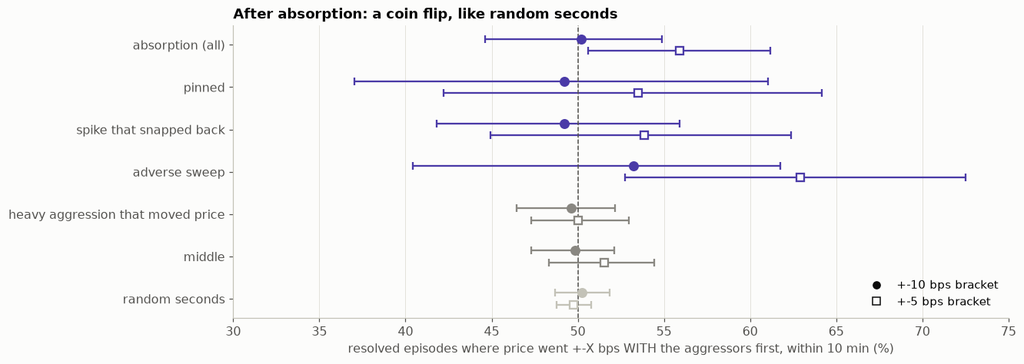

```
absorption +-10 bps: 50.2% [44.6–54.9] (n = 251); +-5 bps: 55.9% [50.6–61.2]; random seconds 50.2% [48.7–51.8]
```

```python
R10, R5 = Q4["resp10_continue_share_resolved"], Q4["revision"]["resp5_and_loo"]["continue5"]
groups = [("absorb_all", "absorption (all)", C["failed"]), ("pinned", "  pinned", C["failed"]),
          ("spike_revert", "  spike that snapped back", C["failed"]), ("adverse_sweep", "  adverse sweep", C["failed"]),
          ("moved", "heavy aggression that moved price", C["ordinary"]), ("middle", "middle", C["ordinary"]),
          ("random", "random seconds", C["random"])]
fig, ax = plt.subplots(figsize=(12, 4.2))
y = np.arange(len(groups))
for dy, src, mk, lab in ((-0.14, R10, "o", "+-10 bps"), (0.14, R5, "s", "+-5 bps")):
    for yi, (k, _, col) in zip(y, groups):
        if k in src:
            e = est(src[k])
            ax.errorbar(e[0] * 100, yi + dy, xerr=[[100 * (e[0] - e[1])], [100 * (e[2] - e[0])]], fmt=mk,
                        ms=7, color=col, ecolor=col, capsize=3,
                        mfc=col if mk == "o" else C["surface"], mew=1.5)
ax.axvline(50, color=C["ink2"], lw=1, ls="--")
ax.set_yticks(y, [g[1] for g in groups])
ax.invert_yaxis()
ax.set_xlim(30, 75)
ax.grid(axis="y", visible=False)
ax.set_xlabel("resolved episodes where price went +-X bps WITH the aggressors first, within 10 min (%)")
ax.legend(handles=[Line2D([], [], ls="", marker="o", color=C["ink"], label="+-10 bps bracket"),
                   Line2D([], [], ls="", marker="s", mfc=C["surface"], color=C["ink"], label="+-5 bps bracket")],
          loc="lower right")
ax.set_title("After absorption: a coin flip, like random seconds")
plt.show()
print(f"absorption +-10 bps: {fmt(est(R10['absorb_all']), d=1)} (n = {R10['absorb_all']['n']}); "
      f"+-5 bps: {fmt(est(R5['absorb_all']), d=1)}; random seconds {fmt(est(R10['random']), d=1)}")
```

```python
note("Share of resolved episodes where price went +-10 bps *with* the aggressors first, within 10 min: "
     "absorption 50.2% [44.6–54.9] (n = 251), heavy aggression that did move price 49.6%, random seconds "
     "50.2%. At +-5 bps: absorption 55.9% [50.6–61.2], random 49.7%. The +-10 bps result holds at every "
     "spike cut and after dropping the most frequent taker wallets. A2 (above) reversed; A4 continued.",
     "**'Effort without result' was not a hold signal.** The CI is about +-5 points, so a small effect is not "
     "excluded. The only lean, at +-5 bps, points toward **continuation**, not reversal; it may be the "
     "in-window adverse move reverting. This agrees with the product's own Tape S/R finding: retests "
     "carrying 'pressure' held *less* often.",
     "**A** (tape, `bbo`, 2 s delay).")
```

**Observation.** Share of resolved episodes where price went +-10 bps *with* the aggressors first, within 10 min: absorption 50.2% [44.6–54.9] (n = 251), heavy aggression that did move price 49.6%, random seconds 50.2%. At +-5 bps: absorption 55.9% [50.6–61.2], random 49.7%. The +-10 bps result holds at every spike cut and after dropping the most frequent taker wallets. A2 (above) reversed; A4 continued.

**Interpretation.** **'Effort without result' was not a hold signal.** The CI is about +-5 points, so a small effect is not excluded. The only lean, at +-5 bps, points toward **continuation**, not reversal; it may be the in-window adverse move reverting. This agrees with the product's own Tape S/R finding: retests carrying 'pressure' held *less* often.

**Class.** **A** (tape, `bbo`, 2 s delay).

#### 4.3 Many of the biggest absorbing orders were position-closing or triggered stop orders

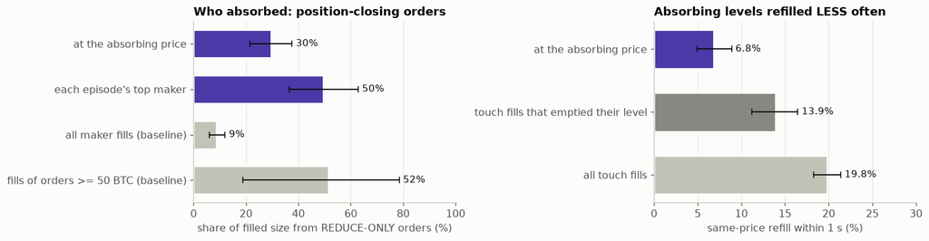

```
how the absorbed size was placed: marketable: took liquidity when placed 7%; placed 1-3 ticks behind 4%; placed >= 4 ticks behind 38%; placed at the touch 31%; placed past the previous block's touch, did not take 11%; trigger order (a stop/TP-type order that activated) 10%
```

```python
AO, RF = Q4["revision"]["absorbing_orders"], Q4["revision"]["refill_v2"]
fig, axs = plt.subplots(1, 2, figsize=(13, 3.3))
ci_bars(axs[0], ["at the absorbing price", "each episode's top maker", "all maker fills (baseline)",
                 "fills of orders >= 50 BTC (baseline)"],
        [est(AO["reduce_only_share_by_size"]), est(AO["reduce_only_share_top_maker_orders_by_size"]),
         est(AO["reduce_only_baseline_hour14"]["all_maker_fills"]),
         est(AO["reduce_only_baseline_hour14"]["fills_of_orders_ge_50btc"])],
        [C["failed"], C["failed"], C["random"], C["random"]], xlim=(0, 100),
        xlabel="share of filled size from REDUCE-ONLY orders (%)")
axs[0].set_title("Who absorbed: position-closing orders")
ci_bars(axs[1], ["at the absorbing price", "touch fills that emptied their level", "all touch fills"],
        [est(Q4["refill"]["absorb_pstar_1s"]), est(RF["touch_level_consumed_1s"]), est(RF["touch_all_adds_1s_(as_before)"])],
        [C["failed"], C["ordinary"], C["random"]], xlim=(0, 30), label_fmt="{:.1f}%",
        xlabel="same-price refill within 1 s (%)")
axs[1].set_title("Absorbing levels refilled LESS often")
plt.show()
pl = AO["placement_share_by_size"]["all"]
print("how the absorbed size was placed: " + "; ".join(f"{k} {100 * v:.0f}%" for k, v in pl.items() if v >= 0.03))
```

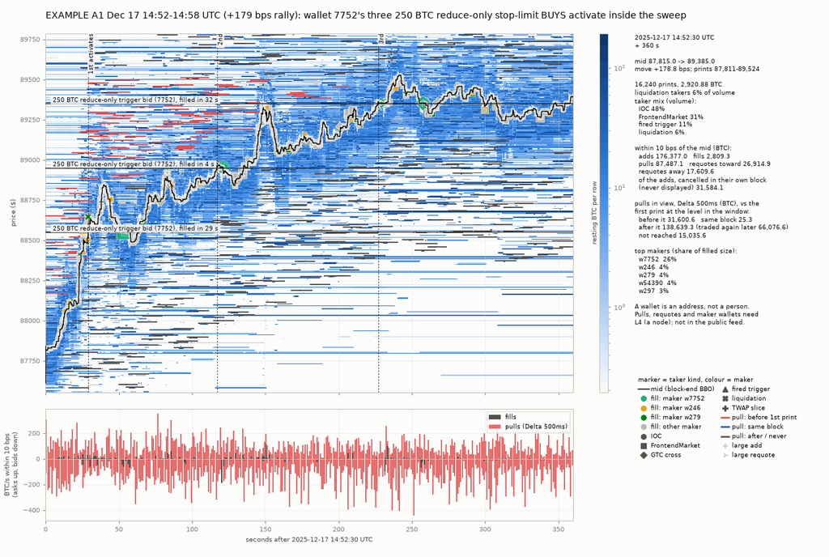

**What to look at:** three very dark rows appear *inside* the rally at the three marked prices: these 'walls' are stop orders that fired, not defenders. Sellers fill each one (in 29 s, 4 s and 32 s) and the rally resumes each time. The counter-example is A3 in 4.1: an ordinary 82 BTC bid at the touch, consumed anyway.

**Observation.** Reduce-only orders supplied 29.5% [21.4–37.6] of the size filled at the absorbing price (49.5% for each episode's top maker), against 8.8% of all maker fills and 52% [19–79] of fills of orders >= 50 BTC. Triggered stop-limit orders supplied 10% of the absorbed size, marketable-limit remainders 7%. Same-price refill within 1 s was rarer at the absorbing price (6.8% [4.9–8.9]) than at ordinary touch fills that also emptied their level (13.9% [11.2–16.5]).

**Interpretation.** A big bid that appears inside a fast move may be a **triggered stop or a closing limit**, not a defender. This is a statement about order flags, not intent. The large-order baseline is wide, so '30%' is clearly above all fills but not clearly above large orders in general.

**Class.** **B-addr** for a known address (REST `frontendOpenOrders` shows its reduce-only and trigger orders before they fire). Otherwise **B-L4**.

```python
render_card(T("2025-12-17 14:52:30"), T("2025-12-17 14:58:30"),
            title="EXAMPLE A1 Dec 17 14:52-14:58 UTC (+179 bps rally): wallet 7752's three 250 BTC reduce-only stop-limit BUYS activate inside the sweep",
            hlines=[(88550, "250 BTC reduce-only trigger bid (7752), filled in 29 s"),
                    (88950, "250 BTC reduce-only trigger bid (7752), filled in 4 s"),
                    (89350, "250 BTC reduce-only trigger bid (7752), filled in 32 s")],
            vlines=[(T("2025-12-17 14:52:59"), "1st activates"), (T("2025-12-17 14:54:27"), "2nd"),
                    (T("2025-12-17 14:56:17"), "3rd")],
            caption="**What to look at:** three very dark rows appear *inside* the rally at the three marked "
                    "prices: these 'walls' are stop orders that fired, not defenders. Sellers fill each one "
                    "(in 29 s, 4 s and 32 s) and the rally resumes each time. The counter-example is A3 in "
                    "4.1: an ordinary 82 BTC bid at the touch, consumed anyway.")
note("Reduce-only orders supplied 29.5% [21.4–37.6] of the size filled at the absorbing price (49.5% for each "
     "episode's top maker), against 8.8% of all maker fills and 52% [19–79] of fills of orders >= 50 BTC. "
     "Triggered stop-limit orders supplied 10% of the absorbed size, marketable-limit remainders 7%. "
     "Same-price refill within 1 s was rarer at the absorbing price (6.8% [4.9–8.9]) than at ordinary touch "
     "fills that also emptied their level (13.9% [11.2–16.5]).",
     "A big bid that appears inside a fast move may be a **triggered stop or a closing limit**, not a "
     "defender. This is a statement about order flags, not intent. The large-order baseline is wide, so '30%' "
     "is clearly above all fills but not clearly above large orders in general.",
     "**B-addr** for a known address (REST `frontendOpenOrders` shows its reduce-only and trigger orders "
     "before they fire). Otherwise **B-L4**.")
```

#### 4.4 One wallet absorbing vs many makers absorbing: no detectable difference

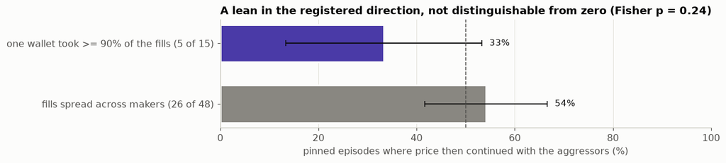

**Interpretation.** The lean points the way the registered H11 expects, but the discovery data cannot tell it from zero. That question is left to H11.

**Class.** Who was filled: **A** after the prints. The same order still resting, or its flags: **B-L4 / B-addr**.

```python
OW = Q4["revision"]["one_wallet_split"]
fig, ax = plt.subplots(figsize=(11, 2.4))
ci_bars(ax, [f"one wallet took >= 90% of the fills ({OW['contingency_[cont,rev]_one_vs_spread'][0][0]} of "
             f"{sum(OW['contingency_[cont,rev]_one_vs_spread'][0])})",
             f"fills spread across makers ({OW['contingency_[cont,rev]_one_vs_spread'][1][0]} of "
             f"{sum(OW['contingency_[cont,rev]_one_vs_spread'][1])})"],
        [est(OW["continue10_one"]), est(OW["continue10_spread"])], [C["failed"], C["ordinary"]],
        xlim=(0, 100), ref=50, xlabel="pinned episodes where price then continued with the aggressors (%)")
ax.set_title(f"A lean in the registered direction, not distinguishable from zero (Fisher p = {OW['fisher_exact_p']:.2f})")
plt.show()
note("Pinned episodes where one wallet took >= 90% of the fills continued 5 of 15 times (33% [13–53]); episodes "
     "with fills spread across makers continued 26 of 48 (54% [42–67]); Fisher p = 0.24. The 17 one-wallet "
     "episodes come from 11 wallets, and the two groups started from different states.",
     "The lean points the way the registered H11 expects, but the discovery data cannot tell it from zero. "
     "That question is left to H11.",
     "Who was filled: **A** after the prints. The same order still resting, or its flags: **B-L4 / B-addr**.")
```

[output not shown]

#### 4.5 Most large displayed orders are one kind of algorithm, and are rarely approached

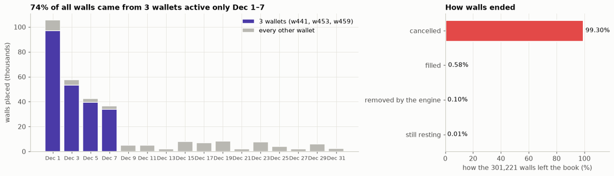

```
walls ever approached within 3 ticks: 5.5% [3.9–10.4]
```

```python
WL = pd.read_parquet(INTERIM / "q4_data/walls_labelled.parquet", columns=["wallet", "day", "exit", "approached"])
for d in WL.day.unique():
    odd_day(d)
top3 = WL.wallet.value_counts().head(3).index.tolist()
per = (WL.assign(who=np.where(WL.wallet.isin(top3), "top", "other")).groupby(["day", "who"]).size()
         .unstack(fill_value=0).reindex(columns=["top", "other"], fill_value=0))
fig, axs = plt.subplots(1, 2, figsize=(13.5, 3.8), gridspec_kw={"width_ratios": [2, 1]})
ax = axs[0]
xd = np.arange(len(per))
ax.bar(xd, per["top"] / 1e3, color=C["failed"], edgecolor=C["surface"], lw=1,
       label="3 wallets (" + ", ".join(f"w{w}" for w in top3) + ")")
ax.bar(xd, per["other"] / 1e3, bottom=per["top"] / 1e3, color=C["added"], edgecolor=C["surface"], lw=1,
       label="every other wallet")
ax.set_xticks(xd, [f"Dec {int(d[-2:])}" for d in per.index], fontsize=8.5)
ax.set_ylabel("walls placed (thousands)")
ax.legend(loc="upper right")
ax.set_title(f"{100 * WL.wallet.isin(top3).mean():.0f}% of all walls came from 3 wallets active only Dec 1–7")
ax = axs[1]
ex = WL.exit.value_counts(normalize=True)
lab = [("cancel", "cancelled"), ("filled", "filled"), ("engine", "removed by the engine"), ("resting", "still resting")]
ax.barh(range(4), [100 * ex.get(k, 0) for k, _ in lab], color=[C["pulled"], C["filled"], C["muted"], C["added"]],
        height=0.62, edgecolor=C["surface"], lw=2)
for i, (k, _) in enumerate(lab):
    ax.text(100 * ex.get(k, 0) + 1.5, i, f"{100 * ex.get(k, 0):.2f}%", va="center", fontsize=9.5)
ax.set_yticks(range(4), [l for _, l in lab])
ax.invert_yaxis()
ax.set_xlim(0, 118)
ax.grid(axis="y", visible=False)
ax.set_xlabel(f"how the {len(WL):,} walls left the book (%)")
ax.set_title("How walls ended")
plt.show()
print(f"walls ever approached within 3 ticks: {fmt(est(Q4['walls']['approached_share']), d=1)}")
```

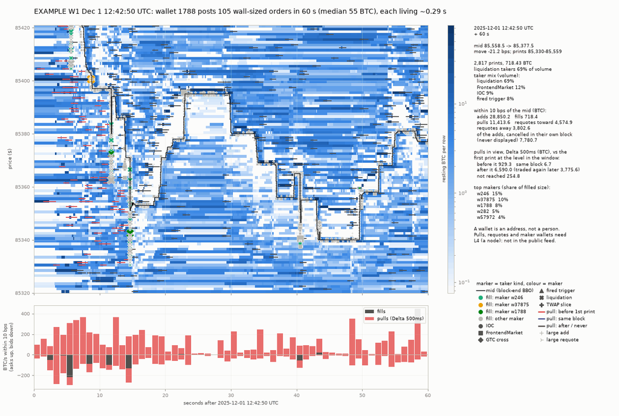

**What to look at:** short dark streaks a few ticks above the mid that appear and vanish (gray requote marks) again and again: one algorithm's inventory at a fixed distance, moving with price. 3 of the 105 got a fill.

**Observation.** 74% of walls came from 3 wallets active only Dec 1–7; their orders lived ~2 s and 0.1–0.2% were ever filled. 99.3% of all walls were cancelled. Only 5.5% [3.9–10.4] were ever approached within 3 ticks.

**Interpretation.** A large number in the book is usually a quoting algorithm's inventory at a fixed distance, and it moves with price.

**Class.** Size and distance: **A** within 20 levels, for an order that lives >= ~0.6 s. About 40% of approached walls lived < 0.6 s: sub-snapshot flicker, **B-L4**.

```python
render_card(T("2025-12-01 12:42:50"), T("2025-12-01 12:43:50"), 85320, 85420,
            title="EXAMPLE W1 Dec 1 12:42:50 UTC: wallet 1788 posts 105 wall-sized orders in 60 s (median 55 BTC), each living ~0.29 s",
            caption="**What to look at:** short dark streaks a few ticks above the mid that appear and vanish "
                    "(gray requote marks) again and again: one algorithm's inventory at a fixed distance, moving "
                    "with price. 3 of the 105 got a fill.")
note("74% of walls came from 3 wallets active only Dec 1–7; their orders lived ~2 s and 0.1–0.2% were ever "
     "filled. 99.3% of all walls were cancelled. Only 5.5% [3.9–10.4] were ever approached within 3 ticks.",
     "A large number in the book is usually a quoting algorithm's inventory at a fixed distance, and it moves "
     "with price.",
     "Size and distance: **A** within 20 levels, for an order that lives >= ~0.6 s. About 40% of approached "
     "walls lived < 0.6 s: sub-snapshot flicker, **B-L4**.")
```

#### 4.6 When price actually reached a large order placed away from it, the order usually traded; whether it was pulled said nothing about direction

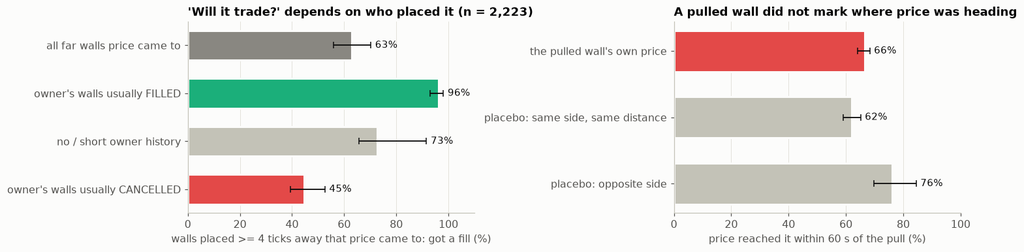

```python
WD, PB = Q4["revision"]["walls_distance"]["approached_added_gt3_ticks"], Q4["revision"]["placebo_60s"]["approached_unfilled_cancels"]
fig, axs = plt.subplots(1, 2, figsize=(13.5, 3.4))
bo = WD["by_owner_prior"]
ci_bars(axs[0], ["all far walls price came to", "owner's walls usually FILLED", "no / short owner history",
                 "owner's walls usually CANCELLED"],
        [est(WD["anyfill"]), est(bo["prior: usually filled"]["anyfill"]), est(bo["no/short history"]["anyfill"]),
         est(bo["prior: usually cancelled"]["anyfill"])],
        [C["muted"], C["success"], C["random"], C["pulled"]], xlim=(0, 110),
        xlabel="walls placed >= 4 ticks away that price came to: got a fill (%)")
axs[0].set_title(f"'Will it trade?' depends on who placed it (n = {WD['anyfill']['n']:,})")
ci_bars(axs[1], ["the pulled wall's own price", "placebo: same side, same distance", "placebo: opposite side"],
        [est(PB["wall_price_reached_60s"]), est(PB["placebo_random_time_same_side_same_dist"]),
         est(PB["placebo_same_time_opposite_side_same_dist"])],
        [C["pulled"], C["random"], C["random"]], xlim=(0, 100),
        xlabel="price reached it within 60 s of the pull (%)")
axs[1].set_title("A pulled wall did not mark where price was heading")
plt.show()
```

**Reconciling with Q2 §2.2.** The two populations differ. Q2 follows **all** size at a range edge, most of it HF inventory cancelled *before* price arrives. Q4.6 follows single large orders that were **still resting** when price got within 3 ticks. Both hold: most displayed size never gets that far, and the big orders that do tend to trade. A1's walls (owner "usually filled") were all filled; the counter-example:

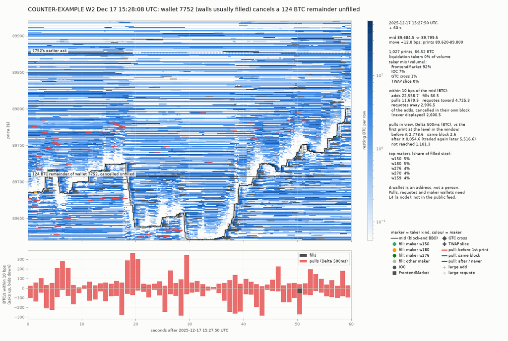

**What to look at:** the dark row at $89,707 is cancelled after 8 s without a fill, and price trades back through $89,707 16 s later.

**Observation.** Of 2,223 walls placed >= 4 ticks from the touch that price later came to, 63% [56–70] got at least a partial fill and 32% were filled in full. The owner's history, from earlier odd days only, separated fates: owners whose walls were 'usually filled' got a fill 96% of the time, 'usually cancelled' owners 45%. This held inside every distance bucket, and owner behaviour persisted day to day (Spearman 0.83). After an approached wall was pulled unfilled, price reached its price within 60 s 66.5% of the time; a placebo level at the same distance 62.1%, the opposite side at the same moment 76.1%.

**Interpretation.** 'Will it trade if price comes?' depended on **where** it was placed and on **who** placed it; neither replaces the other. No book model was fitted, so 'owner beats book' is not claimed. **A pulled wall did not mark where price was heading.**

**Class.** Size and distance: **A**. Owner history: **B-addr** for <= 10 wallets chosen on earlier data. Fate labels: **C**.

```python
render_card(T("2025-12-17 15:27:50"), T("2025-12-17 15:28:50"), 89620, 89920,
            title="COUNTER-EXAMPLE W2 Dec 17 15:28:08 UTC: wallet 7752 (walls usually filled) cancels a 124 BTC remainder unfilled",
            hlines=[(89707, "124 BTC remainder of wallet 7752, cancelled unfilled"), (89876, "7752's earlier ask", ":")],
            caption="**What to look at:** the dark row at $89,707 is cancelled after 8 s without a fill, and "
                    "price trades back through $89,707 16 s later.")
note("Of 2,223 walls placed >= 4 ticks from the touch that price later came to, 63% [56–70] got at least a "
     "partial fill and 32% were filled in full. The owner's history, from earlier odd days only, separated "
     "fates: owners whose walls were 'usually filled' got a fill 96% of the time, 'usually cancelled' owners "
     "45%. This held inside every distance bucket, and owner behaviour persisted day to day (Spearman 0.83). "
     "After an approached wall was pulled unfilled, price reached its price within 60 s 66.5% of the time; a "
     "placebo level at the same distance 62.1%, the opposite side at the same moment 76.1%.",
     "'Will it trade if price comes?' depended on **where** it was placed and on **who** placed it; neither "
     "replaces the other. No book model was fitted, so 'owner beats book' is not claimed. **A pulled wall "
     "did not mark where price was heading.**",
     "Size and distance: **A**. Owner history: **B-addr** for <= 10 wallets chosen on earlier data. Fate "
     "labels: **C**.")
```

### Q5: Liquidity-provider wallets

#### 5.1 Near-price depth sits with a few addresses, more than fills do

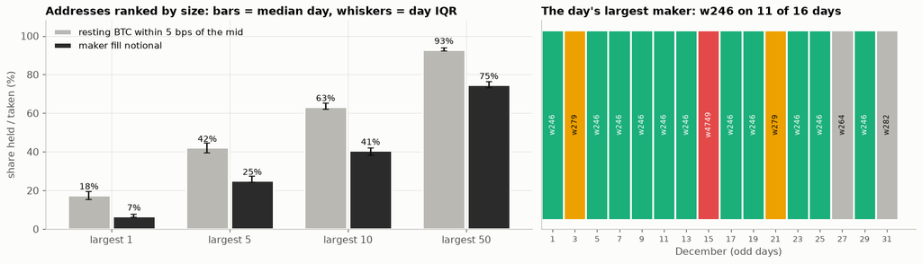

```python
CO = Q5["concentration"]
ks = ["top1", "top5", "top10", "top50"]
fig, axs = plt.subplots(1, 2, figsize=(13.5, 3.8), gridspec_kw={"width_ratios": [1.3, 1]})
ax = axs[0]
x = np.arange(len(ks))
for dx, key, col, lab in ((-0.19, "depth_0_5bps", C["added"], "resting BTC within 5 bps of the mid"),
                          (0.19, "maker_fill_usd", C["filled"], "maker fill notional")):
    med = np.array([CO[key][k]["median"] for k in ks]) * 100
    q25 = np.array([CO[key][k]["q25"] for k in ks]) * 100
    q75 = np.array([CO[key][k]["q75"] for k in ks]) * 100
    ax.bar(x + dx, med, width=0.36, color=col, edgecolor=C["surface"], lw=2, label=lab)
    ax.errorbar(x + dx, med, yerr=[med - q25, q75 - med], fmt="none", ecolor=C["ink"], capsize=3)
    for xi, m in zip(x + dx, med):
        ax.text(xi, m + 3, f"{m:.0f}%", ha="center", fontsize=9)
ax.set_xticks(x, ["largest 1", "largest 5", "largest 10", "largest 50"])
ax.set_ylim(0, 108)
ax.set_ylabel("share held / taken (%)")
ax.legend(loc="upper left")
ax.set_title("Addresses ranked by size: bars = median day, whiskers = day IQR")
ax = axs[1]
tm = pd.DataFrame(Q5["daily_top_maker"])
wallets = tm.wallet.unique().tolist()
pal = {246: C["success"], 279: C["requoted"], 4749: C["pulled"]}
for i, r in tm.iterrows():
    col = pal.get(r.wallet, C["added"])
    ax.barh(0, 1, left=i, color=col, edgecolor=C["surface"], lw=2)
    ax.text(i + 0.5, 0, f"w{r.wallet}", rotation=90, ha="center", va="center", fontsize=8,
            color="white" if col in (C["success"], C["pulled"]) else C["ink"])
ax.set_xticks(np.arange(len(tm)) + 0.5, [f"{int(d[-2:])}" for d in tm.day], fontsize=8.5)
ax.set_yticks([])
ax.grid(False)
ax.set_xlabel("December (odd days)")
ax.set_title(f"The day's largest maker: w246 on {int((tm.wallet == 246).sum())} of {len(tm)} days")
plt.show()
```

**Counter-example, replayed live: Dec 15.** The largest maker that day was wallet **4749**. It placed 1,902 orders, 62% at or inside the touch and 90% bids, and was filled on 3,703 BTC, 88.5% of its fills buys (86% of the BTC), on a falling day. Below, from the warehouse's trades of Dec 15 only: every fill where 4749 was the maker.

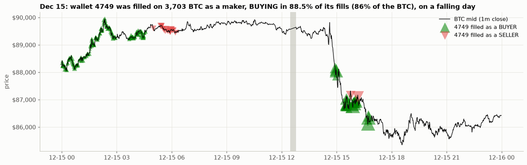

**Observation.** At a random instant the 10 largest holders own 63% (IQR 62–65%) of resting BTC within 5 bps of the mid; 50 own 93%. Fills are less concentrated: the top 10 makers take 41% of maker notional. One address, 0xc6ac…8e84 (dataset id 246), was the largest maker on 11 of 16 days and held ~18% of near-touch depth.

**Interpretation.** Resting size near the touch comes from a small, repeating set of high-frequency addresses. Fills spread wider, because addresses that sit and wait get a larger share of fills than of displayed size. 'The top maker' can be a large passive buyer (4749 on Dec 15), not a liquidity provider.

**Class.** Fill concentration by address: **A** (the tape names makers). Who owns displayed depth: **B-L4**.

```python
if RENDER_LIVE:
    day = odd_day(15)
    d0 = T("2025-12-15 00:00:00")
    parts = []
    for hr in range(24):                                    # Dec 15's own hour files only
        p = DERIVED / "tradesx" / day / f"{hr:02d}.parquet"
        if p.is_file():
            parts.append(pq.read_table(p, columns=["ts", "px", "sz", "aggr_is_ask", "maker_wallet"],
                                       filters=[("maker_wallet", "==", 4749), ("ts", ">=", d0),
                                                ("ts", "<", d0 + 86400 * NS)]).to_pandas())
    mk = pd.concat(parts, ignore_index=True)
    mk["buy"] = mk.aggr_is_ask                              # a sell aggressor hit this maker's bid
    c15 = pq.read_table(DERIVED / "candles" / "1m" / f"{day}.parquet", columns=["t", "c"]).to_pandas()
    fig, ax = plt.subplots(figsize=(13, 4.0))
    ax.plot(pd.to_datetime(c15.t, unit="ns"), c15.c / 10, color=C["ink"], lw=1, label="BTC mid (1m close)")
    m = mk.assign(minute=pd.to_datetime(mk.ts, unit="ns").dt.floor("min")).groupby(["minute", "buy"]).agg(
        btc=("sz", "sum"), px=("px", "mean")).reset_index()
    for b, col, mk_, lab in ((True, C["up"], "^", "4749 filled as a BUYER"), (False, C["down"], "v", "4749 filled as a SELLER")):
        g = m[m.buy == b]
        ax.scatter(g.minute, g.px / 10, s=8 + 6 * g.btc / 1e5, color=col, marker=mk_, alpha=0.55, lw=0, label=lab)
    for g in ODD_GAPS:
        if pd.Timestamp(g.ts_before, unit="ns").strftime("%Y%m%d") == day:
            ax.axvspan(pd.Timestamp(g.ts_before, unit="ns"), pd.Timestamp(g.ts_after, unit="ns"), color=C["random"], alpha=0.6, lw=0)
    ax.yaxis.set_major_formatter(lambda v, _: f"${v:,.0f}")
    ax.set_ylabel("price")
    ax.legend(loc="upper right")
    tot, buys = mk.sz.sum() / 1e5, mk.loc[mk.buy, "sz"].sum() / mk.sz.sum()
    ax.set_title(f"Dec 15: wallet 4749 was filled on {tot:,.0f} BTC as a maker, BUYING in {100 * mk.buy.mean():.1f}% of "
                 f"its fills ({100 * buys:.0f}% of the BTC), on a falling day")
    plt.show()
note("At a random instant the 10 largest holders own 63% (IQR 62–65%) of resting BTC within 5 bps of the mid; "
     "50 own 93%. Fills are less concentrated: the top 10 makers take 41% of maker notional. One address, "
     "0xc6ac…8e84 (dataset id 246), was the largest maker on 11 of 16 days and held ~18% of near-touch depth.",
     "Resting size near the touch comes from a small, repeating set of high-frequency addresses. Fills spread "
     "wider, because addresses that sit and wait get a larger share of fills than of displayed size. 'The top "
     "maker' can be a large passive buyer (4749 on Dec 15), not a liquidity provider.",
     "Fill concentration by address: **A** (the tape names makers). Who owns displayed depth: **B-L4**.")
```

#### 5.2 The makers fall into types that split depth and fills very differently

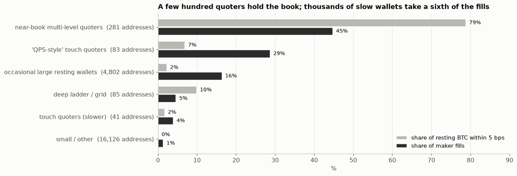

```
cancel within 500 ms of display (share of adds): QPS-style 78%; fill ratio (BTC filled / BTC added): occasional large resting 5.5% vs near-book 0.15%
```

**Observation.** Near-book multi-level quoters (281 addresses) hold 79% of depth within 5 bps and take 45% of maker fills, with size a few bps behind the touch. 'QPS-style' touch quoters (83) hold 7% and take 29%; they cancel 78% of displayed adds within 500 ms. Occasional large resting wallets (4,802) hold 2% and take 16%; they fill 5.5% of what they add, 11–37x the quoters' rate.

**Interpretation.** The book near the touch is re-priced every few hundred ms by a few hundred addresses. The fills are split between them and thousands of slow addresses whose orders sit until hit.

**Class.** The type needs every add and cancel: **B-L4**, or **B-addr** for <= 10 addresses. The pooled labels use all 16 days (hindsight, **C** as a live feature).

```python
TY = pd.DataFrame(Q5["types"]).set_index("type")
order = ["Near-book multi-level quoter", "QPS-style touch quoter", "Occasional large resting",
         "Deep ladder / grid", "Touch quoter (slower)", "Small / other"]
short = {"Near-book multi-level quoter": "near-book multi-level quoters", "QPS-style touch quoter": "'QPS-style' touch quoters",
         "Occasional large resting": "occasional large resting wallets", "Deep ladder / grid": "deep ladder / grid",
         "Touch quoter (slower)": "touch quoters (slower)", "Small / other": "small / other"}
fig, ax = plt.subplots(figsize=(12.5, 4.2))
y = np.arange(len(order))
for dy, col_, colr, lab in ((-0.19, "depth_0_5bps_share", C["added"], "share of resting BTC within 5 bps"),
                            (0.19, "fill_share", C["filled"], "share of maker fills")):
    v = TY.loc[order, col_].to_numpy() * 100
    ax.barh(y + dy, v, height=0.36, color=colr, edgecolor=C["surface"], lw=1.5, label=lab)
    for yi, vi in zip(y + dy, v):
        ax.text(vi + 0.8, yi, f"{vi:.0f}%", va="center", fontsize=9)
ax.set_yticks(y, [f"{short[t]}  ({TY.loc[t, 'n_wallets']:,} addresses)" for t in order])
ax.invert_yaxis()
ax.grid(axis="y", visible=False)
ax.set_xlim(0, 90)
ax.set_xlabel("%")
ax.legend(loc="lower right")
ax.set_title("A few hundred quoters hold the book; thousands of slow wallets take a sixth of the fills")
plt.show()
print("cancel within 500 ms of display (share of adds): QPS-style "
      f"{100 * TY.loc['QPS-style touch quoter', 'churn500'][0]:.0f}%; fill ratio (BTC filled / BTC added): occasional "
      f"large resting {100 * TY.loc['Occasional large resting', 'fill_ratio_btc'][0]:.1f}% vs near-book "
      f"{100 * TY.loc['Near-book multi-level quoter', 'fill_ratio_btc'][0]:.2f}%")
note("Near-book multi-level quoters (281 addresses) hold 79% of depth within 5 bps and take 45% of maker fills, "
     "with size a few bps behind the touch. 'QPS-style' touch quoters (83) hold 7% and take 29%; they cancel "
     "78% of displayed adds within 500 ms. Occasional large resting wallets (4,802) hold 2% and take 16%; they "
     "fill 5.5% of what they add, 11–37x the quoters' rate.",
     "The book near the touch is re-priced every few hundred ms by a few hundred addresses. The fills are split "
     "between them and thousands of slow addresses whose orders sit until hit.",
     "The type needs every add and cancel: **B-L4**, or **B-addr** for <= 10 addresses. The pooled labels use "
     "all 16 days (hindsight, **C** as a live feature).")
```

#### 5.3 When price comes to an order that has rested a few seconds, its owner cancels far more often than its age predicts, and how much depends on the owner

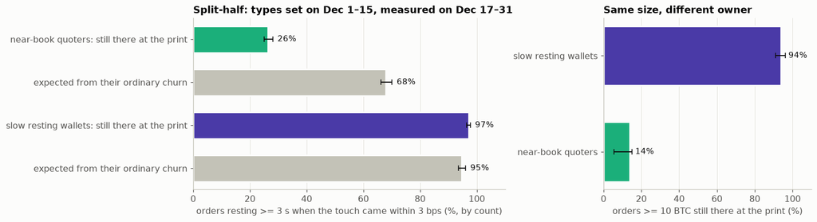

```
by BTC instead of count: near-book 2.0% [1.6–2.5], slow resting 94% [90–98]. All types, all ages (n = 1.52 M): still there 32.2% [30.1–34.5] by count, 9.3% [8.4–10.1] by BTC.
```

```python
SH = Q5["revision"]["split_half"]["rates"]
nb, oc = SH["Near-book multi-level quoter|3bp"]["aged_ge_3s"], SH["Occasional large resting|3bp"]["aged_ge_3s"]
fig, axs = plt.subplots(1, 2, figsize=(13.5, 3.6), gridspec_kw={"width_ratios": [1.5, 1]})
ci_bars(axs[0], ["near-book quoters: still there at the print", "  expected from their ordinary churn",
                 "slow resting wallets: still there at the print", "  expected from their ordinary churn"],
        [est(nb["there"]), est(nb["baseline"]["exp_there_if_ordinary_churn"]), est(oc["there"]),
         est(oc["baseline"]["exp_there_if_ordinary_churn"])],
        [C["success"], C["random"], C["failed"], C["random"]], xlim=(0, 110),
        xlabel="orders resting >= 3 s when the touch came within 3 bps (%, by count)")
axs[0].set_title("Split-half: types set on Dec 1–15, measured on Dec 17–31")
SZ = Q5["revision"]["size_ge10"]["by_type"]
ci_bars(axs[1], ["slow resting wallets", "near-book quoters"],
        [est(SZ["Occasional large resting"]["there_wallet_ci"]), est(SZ["Near-book multi-level quoter"]["there_wallet_ci"])],
        [C["failed"], C["success"]], xlim=(0, 110), xlabel="orders >= 10 BTC still there at the print (%)")
axs[1].set_title("Same size, different owner")
plt.show()
print(f"by BTC instead of count: near-book {fmt(est(nb['there_btc']), d=1)}, slow resting {fmt(est(oc['there_btc']))}. "
      "All types, all ages (n = 1.52 M): still there "
      f"{fmt(est(Q5['revision']['headline_3bp_resting_ge_3s']['there']), d=1)} by count, "
      f"{fmt(est(Q5['revision']['headline_3bp_resting_ge_3s']['there_btc']), d=1)} by BTC.")
```

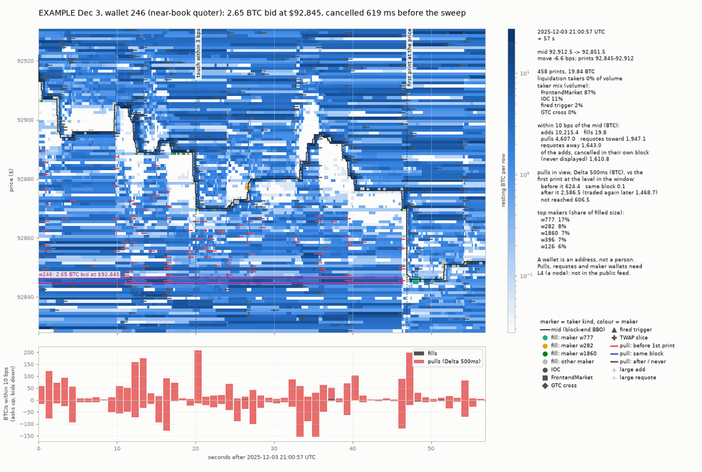

**What to look at:** the outlined order ends (red dash) just before the first print at its price: approached at 21:01:17.130, cancelled 619 ms before a sell sweep printed there at 21:01:44.039.

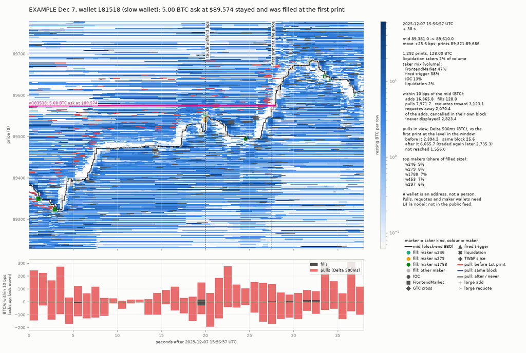

**What to look at:** the outlined order rests untouched until price arrives and fills it (15:57:25.355): the slow wallets' size is the size that stays.

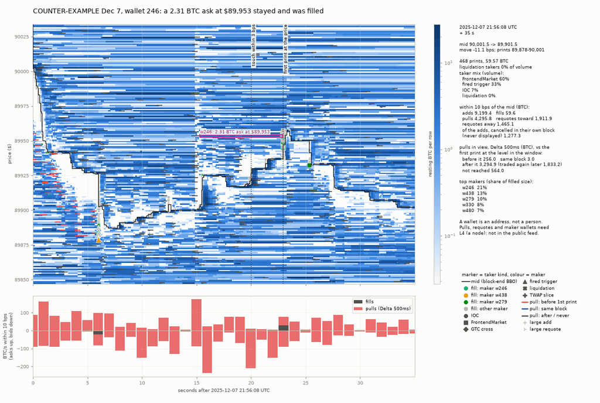

**What to look at:** the same near-book quoter as the first example, but this time its order stays and is filled at the first print (21:56:31.406).

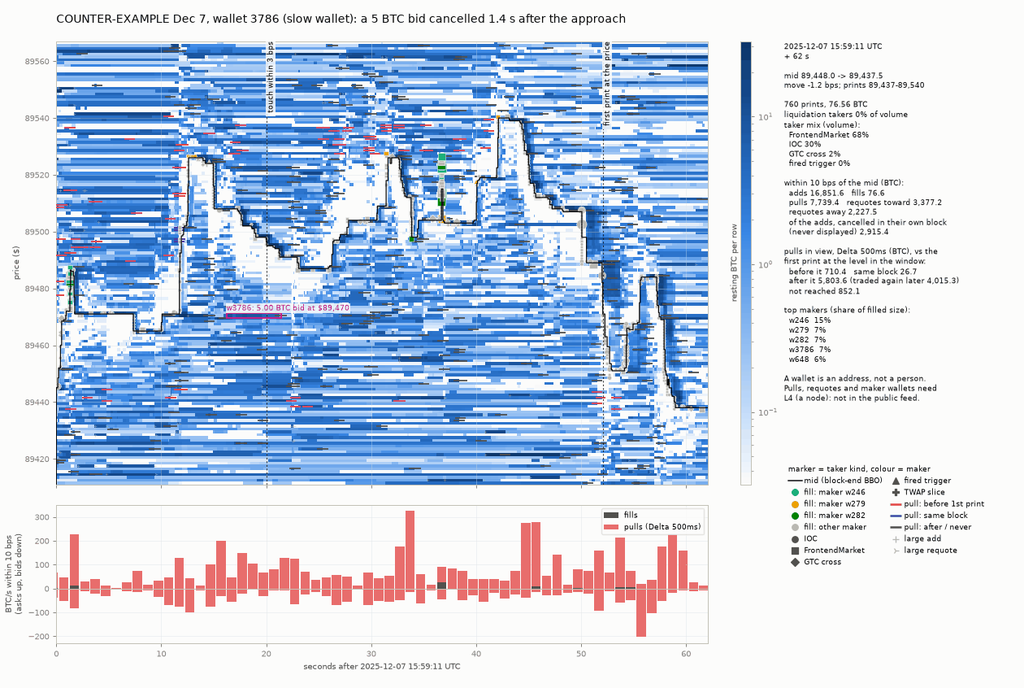

**What to look at:** a slow wallet's order that *was* pulled as price came (then re-placed 21 s later at the same distance and filled).

**Observation.** Orders resting >= 3 s when the touch came within 3 bps and printed at within 60 s (n = 1.52 M, 16 days): 32.2% [30.1–34.5] by count, and only 9.3% [8.4–10.1] by BTC, were still there at the first print; owners cancelled 26.2% within 2 s of the approach (9.4% for the same wallets' same-age orders that price did not come to); 70% were cancelled before the print against 33% expected from ordinary churn. Split-half: near-book quoters 26% still there (2% of their BTC) vs 68% expected; slow resting wallets 97% (94% of BTC) vs 95%. Of the ~71-point gap, ~27 points is order lifetimes and ~44 points is extra cancelling when price comes. About half the cancelled size is pulled and half re-posted nearby. Orders >= 10 BTC: still there 94% of the time when a slow wallet owned them, 14% when a near-book quoter did.

**Interpretation.** Whether a displayed order will still be there depends mostly on who posted it. The high-frequency addresses withdraw or move size as price approaches, well beyond their normal churn; the size that stays belongs to slow addresses, whose behaviour does not change. **The public book does not show the owner.**

**Class.** Ownership, age, pull vs requote: **B-L4**, or **B-addr** for <= 10 followed addresses (their cancels arrive in ~0.4 s). Order size alone is **not a usable class-A cue**.

```python
EX5 = {e["example"]: e for e in Q5["examples"]}
for e in EX5.values():
    odd_day(e["day"])


def q5_card(key, title, caption):
    e = EX5[key]
    t0, t1 = T(e["window_utc"][0]), T(e["window_utc"][1])
    lo, hi = price_range(t0, t1, include=[e["px_usd"]], pad_frac=0.25)
    box = [(T(e["added_utc"]), T(e["exit_utc"]),
            e["px_usd"], f"w{e['wallet_id']}: {e['size_btc']:.2f} BTC {e['side']} at ${e['px_usd']:,.0f}")]
    vl = [(T(e["approach_utc"]), "touch within 3 bps"), (T(e["first_print_utc"]), "first print at the price")]
    return render_card(t0, t1, lo, hi, title=title, boxes=box, vlines=vl, caption=caption)


q5_card("A1_nearbook_pulled_early",
        "EXAMPLE Dec 3, wallet 246 (near-book quoter): 2.65 BTC bid at $92,845, cancelled 619 ms before the sweep",
        "**What to look at:** the outlined order ends (red dash) just before the first print at its price: "
        "approached at 21:01:17.130, cancelled 619 ms before a sell sweep printed there at 21:01:44.039.")
q5_card("B1_occasional_stayed_filled",
        "EXAMPLE Dec 7, wallet 181518 (slow wallet): 5.00 BTC ask at $89,574 stayed and was filled at the first print",
        "**What to look at:** the outlined order rests untouched until price arrives and fills it "
        "(15:57:25.355): the slow wallets' size is the size that stays.")
q5_card("A3_counter_nearbook_stayed_filled",
        "COUNTER-EXAMPLE Dec 7, wallet 246: a 2.31 BTC ask at $89,953 stayed and was filled",
        "**What to look at:** the same near-book quoter as the first example, but this time its order stays and "
        "is filled at the first print (21:56:31.406).")
q5_card("B2_counter_occasional_pulled",
        "COUNTER-EXAMPLE Dec 7, wallet 3786 (slow wallet): a 5 BTC bid cancelled 1.4 s after the approach",
        "**What to look at:** a slow wallet's order that *was* pulled as price came (then re-placed 21 s later at "
        "the same distance and filled).")
note("Orders resting >= 3 s when the touch came within 3 bps and printed at within 60 s (n = 1.52 M, 16 days): "
     "32.2% [30.1–34.5] by count, and only 9.3% [8.4–10.1] by BTC, were still there at the first print; owners "
     "cancelled 26.2% within 2 s of the approach (9.4% for the same wallets' same-age orders that price did not "
     "come to); 70% were cancelled before the print against 33% expected from ordinary churn. Split-half: "
     "near-book quoters 26% still there (2% of their BTC) vs 68% expected; slow resting wallets 97% (94% of "
     "BTC) vs 95%. Of the ~71-point gap, ~27 points is order lifetimes and ~44 points is extra cancelling when "
     "price comes. About half the cancelled size is pulled and half re-posted nearby. Orders >= 10 BTC: still "
     "there 94% of the time when a slow wallet owned them, 14% when a near-book quoter did.",
     "Whether a displayed order will still be there depends mostly on who posted it. The high-frequency "
     "addresses withdraw or move size as price approaches, well beyond their normal churn; the size that stays "
     "belongs to slow addresses, whose behaviour does not change. **The public book does not show the owner.**",
     "Ownership, age, pull vs requote: **B-L4**, or **B-addr** for <= 10 followed addresses (their cancels "
     "arrive in ~0.4 s). Order size alone is **not a usable class-A cue**.")
```

#### 5.4 After a fill, price on average drifted against the makers who waited

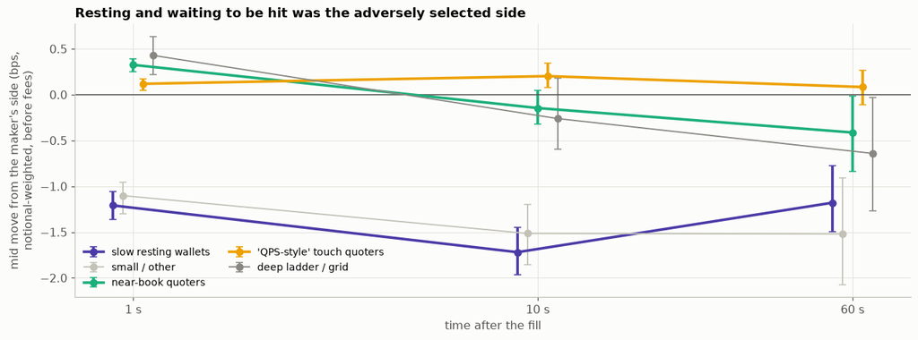

**Observation.** Mid move after a fill, from the maker's side, before fees: slow resting wallets, notional-weighted, -1.2 bps (1 s), -1.7 (10 s), -1.2 (60 s); per fill the median is -0.5 bps with 44–47% of fills at or in the maker's favour. QPS-style touch quoters about flat (+0.2 bps at 10 s). The 952 slow-wallet orders >= 5 BTC filled at the first print: median -0.1 bps at 60 s, 49% positive. Examples: wallet 246's filled ask in 5.3 +12 bps at 60 s; wallet 181518's ask -7.3 bps at 1 s, then +9.2 at 60 s. Counter-example: wallet 7719 on Dec 7, one bid +30 bps at 60 s, another -30 bps the same day.

**Interpretation.** On average, resting a limit order and waiting to be hit was the adversely selected side, before the 1.5 bps tier-0 maker fee. Single fills are very noisy (IQR ~9 bps at 60 s).

**Class.** Per-address fill markouts: **A** after the fill (maker addresses are public).

```python
hz = [1, 10, 60]
show = [("Occasional large resting", "slow resting wallets", C["failed"], 2.4),
        ("Small / other", "small / other", C["random"], 1.2),
        ("Near-book multi-level quoter", "near-book quoters", C["success"], 2.4),
        ("QPS-style touch quoter", "'QPS-style' touch quoters", C["requoted"], 2.4),
        ("Deep ladder / grid", "deep ladder / grid", C["muted"], 1.2)]
fig, ax = plt.subplots(figsize=(11.5, 4.2))
for j, (t, lab, col, lw) in enumerate(show):
    tri = np.array([est(TY.loc[t, f"mk{h}"]) for h in hz])
    xx = np.log10(hz) + (j - 2) * 0.025
    ax.errorbar(xx, tri[:, 0], yerr=[tri[:, 0] - tri[:, 1], tri[:, 2] - tri[:, 0]], fmt="o-", lw=lw, ms=6,
                color=col, ecolor=col, capsize=3, label=lab)
ax.axhline(0, color=C["ink2"], lw=1)
ax.set_xticks(np.log10(hz), ["1 s", "10 s", "60 s"])
ax.set_xlabel("time after the fill")
ax.set_ylabel("mid move from the maker's side (bps,\nnotional-weighted, before fees)")
ax.legend(loc="lower left", ncol=2, fontsize=9)
ax.set_title("Resting and waiting to be hit was the adversely selected side")
plt.show()
note("Mid move after a fill, from the maker's side, before fees: slow resting wallets, notional-weighted, "
     "-1.2 bps (1 s), -1.7 (10 s), -1.2 (60 s); per fill the median is -0.5 bps with 44–47% of fills at or in "
     "the maker's favour. QPS-style touch quoters about flat (+0.2 bps at 10 s). The 952 slow-wallet orders "
     ">= 5 BTC filled at the first print: median -0.1 bps at 60 s, 49% positive. Examples: wallet 246's filled "
     "ask in 5.3 +12 bps at 60 s; wallet 181518's ask -7.3 bps at 1 s, then +9.2 at 60 s. Counter-example: "
     "wallet 7719 on Dec 7, one bid +30 bps at 60 s, another -30 bps the same day.",
     "On average, resting a limit order and waiting to be hit was the adversely selected side, before the "
     "1.5 bps tier-0 maker fee. Single fills are very noisy (IQR ~9 bps at 60 s).",
     "Per-address fill markouts: **A** after the fill (maker addresses are public).")
```

#### 5.5 Who the makers are is stable; how well their fills do is not

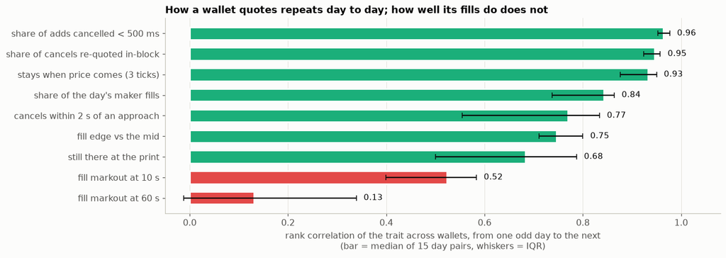

```
ten makers chosen on earlier days covered 38% of the next day's maker fills and 52% of its near-touch depth (medians); 38 of each day's top-50 makers are in the next odd day's top 50.
```

**Observation.** How a wallet quotes is stable: day-to-day rank correlation 0.93–0.96; a median 38 of each day's top-50 makers are in the next odd day's top 50. Ten makers chosen on earlier days covered 38% of the next day's maker fills and 52% of its near-touch depth. Fill markouts are not stable: rho 0.52 at 10 s, 0.13 at 60 s. Counter-example: on the quiet Saturdays (Dec 13 and 27) traits shifted: the day-to-day correlation of cancel-on-approach fell to 0.42, and wallet 246 cancelled half as often.

**Interpretation.** The data supports a watch list ('these addresses are the book'). It does not support a ranking of 'informed' makers.

**Class.** **B-addr**: `orderUpdates` for <= 10 addresses per IP, free, ~0.4 s. Whether December's addresses are still active today is **untested**.

```python
ST = Q5["stability_day_to_day"]
traits = [("churn500", "share of adds cancelled < 500 ms"), ("rq_blk_share", "share of cancels re-quoted in-block"),
          ("stay_reg_3t", "stays when price comes (3 ticks)"), ("fill_share", "share of the day's maker fills"),
          ("cxl2_3bp", "cancels within 2 s of an approach"), ("edge", "fill edge vs the mid"),
          ("there_3bp", "still there at the print"), ("mk10", "fill markout at 10 s"), ("mk60", "fill markout at 60 s")]
fig, ax = plt.subplots(figsize=(12, 4.2))
med = np.array([ST[k]["rho"]["median"] for k, _ in traits])
q25 = np.array([ST[k]["rho"]["q25"] for k, _ in traits])
q75 = np.array([ST[k]["rho"]["q75"] for k, _ in traits])
cols = [C["success"] if k not in ("mk10", "mk60") else C["pulled"] for k, _ in traits]
y = np.arange(len(traits))
ax.barh(y, med, color=cols, height=0.62, edgecolor=C["surface"], lw=2)
ax.errorbar(med, y, xerr=[med - q25, q75 - med], fmt="none", ecolor=C["ink"], capsize=3)
for yi, m, hi in zip(y, med, q75):
    ax.text(hi + 0.015, yi, f"{m:.2f}", va="center", fontsize=9.5)
ax.set_yticks(y, [t[1] for t in traits])
ax.invert_yaxis()
ax.set_xlim(-0.05, 1.08)
ax.grid(axis="y", visible=False)
ax.set_xlabel("rank correlation of the trait across wallets, from one odd day to the next\n(bar = median of 15 day pairs, whiskers = IQR)")
ax.set_title("How a wallet quotes repeats day to day; how well its fills do does not")
plt.show()
BA = Q5["baddr_top10_prior_coverage"]
print(f"ten makers chosen on earlier days covered {100 * BA['fill_share']['median']:.0f}% of the next day's maker "
      f"fills and {100 * BA['depth5_share']['median']:.0f}% of its near-touch depth (medians); "
      f"{Q5['top50_persistence_next_odd_day']['median']:.0f} of each day's top-50 makers are in the next odd day's top 50.")
note("How a wallet quotes is stable: day-to-day rank correlation 0.93–0.96; a median 38 of each day's top-50 "
     "makers are in the next odd day's top 50. Ten makers chosen on earlier days covered 38% of the next day's "
     "maker fills and 52% of its near-touch depth. Fill markouts are not stable: rho 0.52 at 10 s, 0.13 at "
     "60 s. Counter-example: on the quiet Saturdays (Dec 13 and 27) traits shifted: the day-to-day "
     "correlation of cancel-on-approach fell to 0.42, and wallet 246 cancelled half as often.",
     "The data supports a watch list ('these addresses are the book'). It does not support a ranking of "
     "'informed' makers.",
     "**B-addr**: `orderUpdates` for <= 10 addresses per IP, free, ~0.4 s. Whether December's addresses are "
     "still active today is **untested**.")
```

### Q6: Does anything in the book or tape predict the next move at a manual delay?

**Scope.** Three event families on 16 odd days:

| Family | Definition | Events |
| --- | --- | --- |
| one-sided **execution bursts** | ≥ $2.56M net in 5 s | 2,820 |
| **sweeps** | ≥ 2 bps through the book in one block | 9,930 |
| near-touch **pull bursts** | size pulled within ~5 bps of the mid over 2 s, ≥ the 90th percentile relative to the depth there, mostly on one side | 25,475 |

Comparisons: a regression on the events plus 135,824 ordinary seconds, controlling for the trailing move, the last-second jump, the spread, volatility, the hour and the Binance move (**"beyond comparable seconds"** below); and matched controls (only 55–63% of events found a match). Entry delays of 0, 2 and 5 s.

#### 6.0 HL's mid trails Binance by ~0.7 s, on every odd day

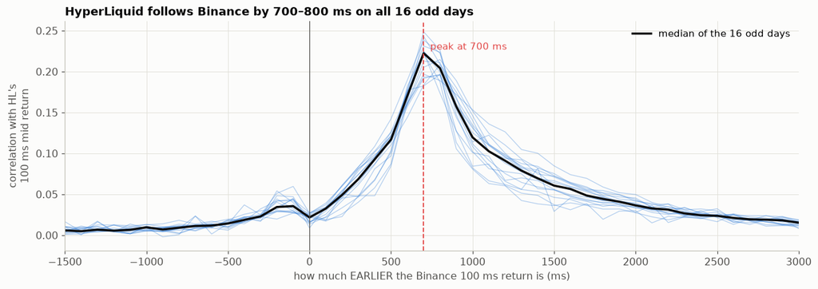

```
1 s returns: correlation 0.30 in the same second, 0.64 with Binance's previous second (day medians)
```

```python
LL = json.loads((INTERIM / "q6q7_work/leadlag.json").read_text())
LL = {d: v for d, v in LL.items() if d.isdigit()}
for d in LL:
    odd_day(d)
fig, ax = plt.subplots(figsize=(11.5, 4.0))
curves = []
for d, v in sorted(LL.items()):
    s = pd.Series(v["c_at"], dtype=float)
    s.index = s.index.astype(int)
    s = s.sort_index()
    curves.append(s)
    ax.plot(s.index, s.values, color=C["fast"], lw=0.8, alpha=0.35)
med = pd.concat(curves, axis=1).median(axis=1)
ax.plot(med.index, med.values, color=C["ink"], lw=2.2, label="median of the 16 odd days")
lag = Q67["q6"]["binance_leadlag"]["lstar_ms_median"]
ax.axvline(lag, color=C["pulled"], lw=1.2, ls="--")
ax.text(lag + 40, med.max() * 1.02, f"peak at {lag:.0f} ms", color=C["pulled"], fontsize=9.5)
ax.axvline(0, color=C["ink2"], lw=0.8)
ax.set_xlim(-1500, 3000)
ax.set_xlabel("how much EARLIER the Binance 100 ms return is (ms)")
ax.set_ylabel("correlation with HL's\n100 ms mid return")
ax.legend(loc="upper right")
ax.set_title("HyperLiquid follows Binance by 700–800 ms on all 16 odd days")
plt.show()
bl = Q67["q6"]["binance_leadlag"]
print(f"1 s returns: correlation {bl['corr_1s_lag0_median']:.2f} in the same second, "
      f"{bl['corr_1s_lag1_median']:.2f} with Binance's previous second (day medians)")
```

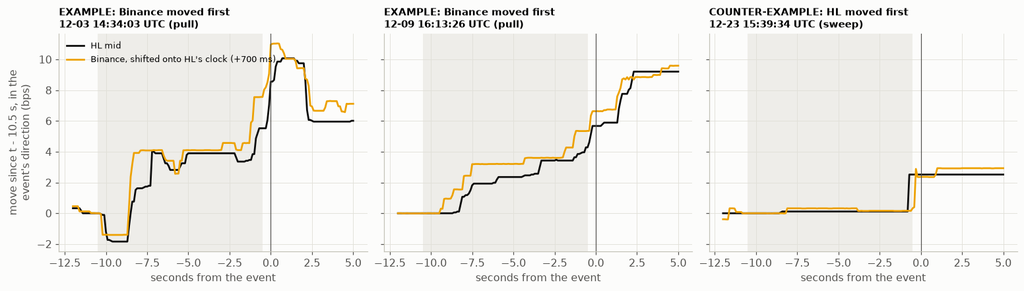

**Observation.** 100 ms returns correlate best with Binance 700–800 ms earlier on all 16 days (median 700 ms). For 1 s returns, the correlation is 0.30 in the same second and 0.64 with Binance's previous second. Events that Binance led (15–18%) moved a little more afterwards, but no more than ordinary seconds with the same Binance move. Examples: Dec 3 14:34:03 (Binance +7.6 bps vs HL +5.5 before the event; +12.8 after) and Dec 9 16:13:26 (+5.4 vs +4.3; then -11.6). Counter-example: Dec 23 15:39:34, an HL sweep with HL +2.5 bps while Binance moved +0.3.

**Interpretation.** The information is in the Binance move, not in the HL event. A clock offset and a true lead cannot be separated (HL stamps block times). 0.7 s is also below the ~0.9 s manual reaction floor.

**Class.** **A**.

```python
BN = Q67C = json.loads((INTERIM / "q6q7_work/cards2.json").read_text())
picks = [c for c in BN["binance"]["cards"] if c["day"] in ("20251203", "20251209", "20251223")]
if RENDER_LIVE:
    fig, axs = plt.subplots(1, len(picks), figsize=(14, 3.9), sharey=True)
    for ax, r in zip(axs, picks):
        day = odd_day(r["day"])
        b = pd.read_parquet(INTERIM / f"q6q7_work/base_{day}.parquet", columns=["mid", "bn_px"])
        ds = T(f"{day[:4]}-{day[4:6]}-{day[6:]} 00:00:00")
        k = int(np.ceil((r["t_ns"] - ds) / 1e8))
        lagk = int(round(LL[day]["lstar_100ms_ms"] / 100))
        xk = np.arange(-120, 51)
        mid, bn, bnal = (b["mid"].to_numpy()[k + xk], b["bn_px"].to_numpy()[k + xk],
                         b["bn_px"].to_numpy()[k + xk - lagk])
        s, i0 = r["s"], 15
        ax.plot(xk / 10, s * 1e4 * np.log(mid / mid[i0]), color=C["ink"], lw=1.8, label="HL mid")
        ax.plot(xk / 10, s * 1e4 * np.log(bnal / bnal[i0]), color=C["requoted"], lw=1.8,
                label=f"Binance, shifted onto HL's clock (+{lagk * 100} ms)")
        ax.axvspan(-10.5, -0.5, color=C["grid"], alpha=0.5, lw=0)
        ax.axvline(0, color=C["ink2"], lw=0.8)
        role = "COUNTER-EXAMPLE: HL moved first" if "counter" in r["role"] else "EXAMPLE: Binance moved first"
        ax.set_title(f"{role}\n{utc(r['t_ns'])[5:19]} UTC ({r['fam']})", fontsize=10)
        ax.set_xlabel("seconds from the event")
    axs[0].set_ylabel("move since t - 10.5 s, in the\nevent's direction (bps)")
    axs[0].legend(loc="upper left", fontsize=8.5)
    plt.show()
note("100 ms returns correlate best with Binance 700–800 ms earlier on all 16 days (median 700 ms). For 1 s "
     "returns, the correlation is 0.30 in the same second and 0.64 with Binance's previous second. Events "
     "that Binance led (15–18%) moved a little more afterwards, but no more than ordinary seconds with the "
     "same Binance move. Examples: Dec 3 14:34:03 (Binance +7.6 bps vs HL +5.5 before the event; +12.8 after) "
     "and Dec 9 16:13:26 (+5.4 vs +4.3; then -11.6). Counter-example: Dec 23 15:39:34, an HL sweep with HL "
     "+2.5 bps while Binance moved +0.3.",
     "The information is in the Binance move, not in the HL event. A clock offset and a true lead cannot be "
     "separated (HL stamps block times). 0.7 s is also below the ~0.9 s manual reaction floor.",
     "**A**.")
```

#### 6.1 By the time an execution burst is visible, the move has mostly happened

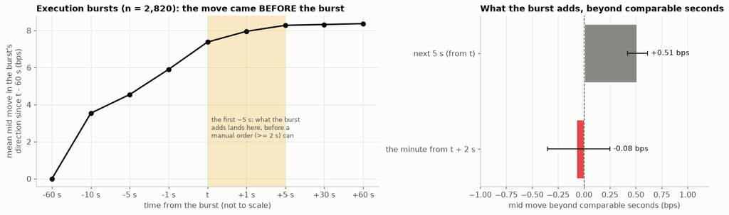

```
A taker round trip costs 9 bps at tier 0; these effects are a few tenths of a bp.
```

```python
EXG = Q67["q6"]["exec"]["groups"]["all"]
pre, fwd, reg = EXG["pre"], EXG["fwd"], EXG["reg"]
p60 = pre["pre60"]["mean"]
pts = [(-60, 0.0), (-10, p60 - pre["pre10"]["mean"]), (-5, p60 - pre["pre5"]["mean"]),
       (-1, p60 - pre["pre1"]["mean"]), (0, p60)] + [(h, p60 + fwd[f"d0_H{h}"]["mean"]) for h in (1, 5, 30, 60)]
fig, axs = plt.subplots(1, 2, figsize=(13.5, 4.0), gridspec_kw={"width_ratios": [1.5, 1]})
ax = axs[0]
xx, yy = zip(*pts)
pos = np.arange(len(xx))
ax.plot(pos, yy, "o-", color=C["ink"], lw=2, ms=6)
i0 = xx.index(0)
ax.axvspan(i0, i0 + 2, color=C["requoted"], alpha=0.22, lw=0)
ax.text(i0 + 0.1, p60 * 0.3, "the first ~5 s: what the burst\nadds lands here, before a\nmanual order (>= 2 s) can", fontsize=8.5,
        color=C["ink2"])
ax.set_xticks(pos, [("t" if v == 0 else f"{v:+d} s") for v in xx])
ax.set_xlabel("time from the burst (not to scale)")
ax.set_ylabel("mean mid move in the burst's\ndirection since t - 60 s (bps)")
ax.set_title(f"Execution bursts (n = {EXG['n']:,}): the move came BEFORE the burst")
ax = axs[1]
ci_bars(ax, ["next 5 s (from t)", "the minute from t + 2 s"], [est(reg["R_d0_H5"]), est(reg["R_d2_H60"])],
        [C["muted"], C["pulled"]], scale=1, label_fmt="{:+.2f} bps", xlim=(-1, 1.2), ref=0.0,
        xlabel="mid move beyond comparable seconds (bps)")
ax.set_title("What the burst adds, beyond comparable seconds")
plt.show()
print("A taker round trip costs 9 bps at tier 0; these effects are a few tenths of a bp.")
```

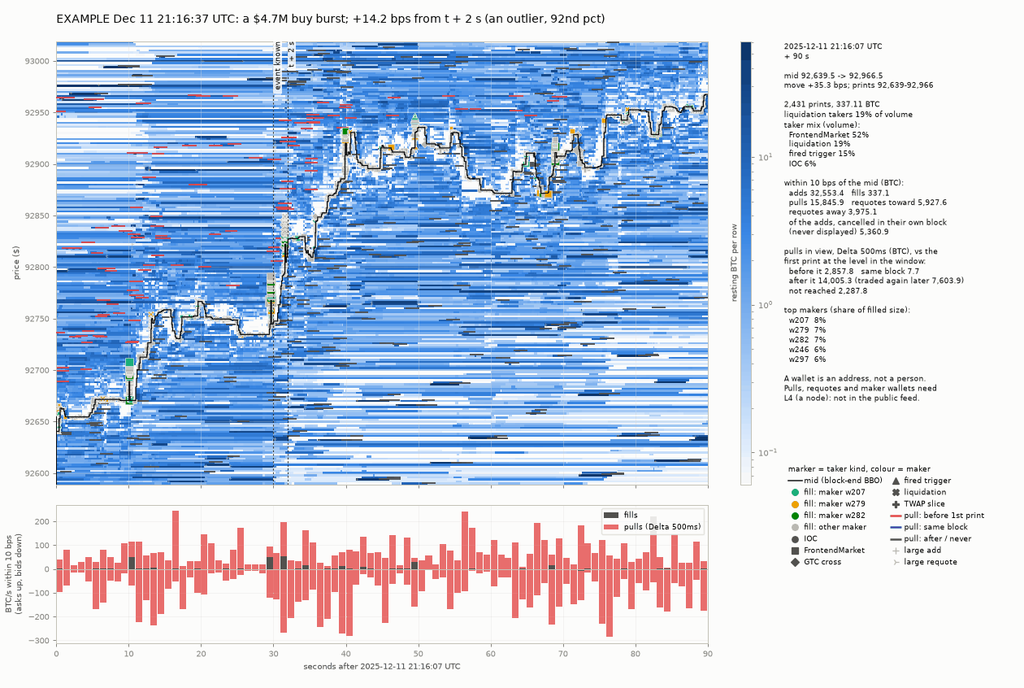

**What to look at:** the burst of buy prints at the 30 s mark, and the continuation after it. This one ran, but it sits at the 92nd percentile of its family: the tail of a symmetric distribution.

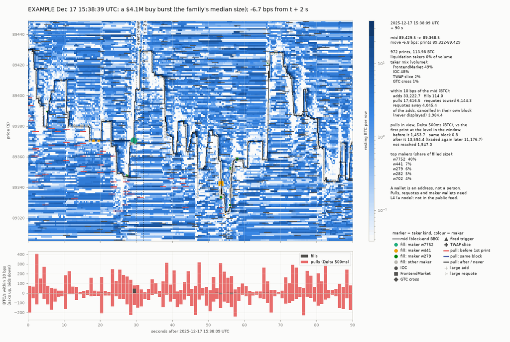

**What to look at:** the mid had already risen into the burst; after it, the price drifts back.

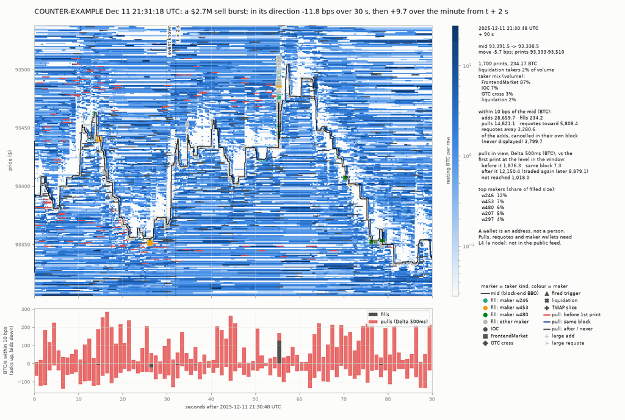

**What to look at:** the sell burst at the 30 s mark, then a sharp bounce UP (-11.8 bps in the burst's direction over 30 s), then a fall back down (+9.7 bps with the burst over the minute from t + 2 s). Single events swing both ways; the average is what carries no information.

**Observation.** Before a burst the mid had already moved +7.4 bps over the prior minute. Beyond comparable seconds: +0.51 [+0.42, +0.61] bps over the next 5 s, but -0.08 [-0.35, +0.25] over the minute from t + 2 s. The largest bursts move +2.0 bps in the first second, partly the spread re-tightening, which a taker cannot collect.

**Interpretation.** A big one-sided burst marks the **end of the fast part**. Whatever it adds arrives within ~5 s, where a manual trader cannot act, and is far below fees.

**Class.** **A** (the tape carries aggressor side and size). The stop/liquidation split: **B-L4**.

```python
def q6_card(t_utc, title, caption):
    t = T(t_utc)
    return render_card(t - 30 * NS, t + 60 * NS, title=title, vlines=[(t, "event known"), (t + 2 * NS, "t + 2 s")],
                       caption=caption)


q6_card("2025-12-11 21:16:37", "EXAMPLE Dec 11 21:16:37 UTC: a $4.7M buy burst; +14.2 bps from t + 2 s (an outlier, 92nd pct)",
        "**What to look at:** the burst of buy prints at the 30 s mark, and the continuation after it. This one "
        "ran, but it sits at the 92nd percentile of its family: the tail of a symmetric distribution.")
q6_card("2025-12-17 15:38:39", "EXAMPLE Dec 17 15:38:39 UTC: a $4.1M buy burst (the family's median size); -6.7 bps from t + 2 s",
        "**What to look at:** the mid had already risen into the burst; after it, the price drifts back.")
q6_card("2025-12-11 21:31:18", "COUNTER-EXAMPLE Dec 11 21:31:18 UTC: a $2.7M sell burst; in its direction -11.8 bps over 30 s, then +9.7 over the minute from t + 2 s",
        "**What to look at:** the sell burst at the 30 s mark, then a sharp bounce UP (-11.8 bps in the burst's "
        "direction over 30 s), then a fall back down (+9.7 bps with the burst over the minute from t + 2 s). "
        "Single events swing both ways; the average is what carries no information.")
note("Before a burst the mid had already moved +7.4 bps over the prior minute. Beyond comparable seconds: "
     "+0.51 [+0.42, +0.61] bps over the next 5 s, but -0.08 [-0.35, +0.25] over the minute from t + 2 s. The "
     "largest bursts move +2.0 bps in the first second, partly the spread re-tightening, which a taker cannot "
     "collect.",
     "A big one-sided burst marks the **end of the fast part**. Whatever it adds arrives within ~5 s, where a "
     "manual trader cannot act, and is far below fees.",
     "**A** (the tape carries aggressor side and size). The stop/liquidation split: **B-L4**.")
```

#### 6.2 Pull bursts mostly follow a price move, and sweeps add nothing after the first second

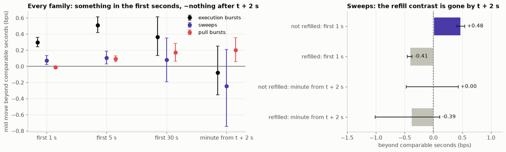

```
pull bursts: the mid moved AGAINST the burst's direction while the pulls were counted in 52% [47–55] of events (with it 37% [34–41], flat 11% [10–13]).
```

```python
fams = [("exec", "execution bursts", C["ink"]), ("sweep", "sweeps", C["failed"]), ("pull", "pull bursts", C["pulled"])]
hs = [("R_d0_H1", "first 1 s"), ("R_d0_H5", "first 5 s"), ("R_d0_H30", "first 30 s"), ("R_d2_H60", "minute from t + 2 s")]
fig, axs = plt.subplots(1, 2, figsize=(13.5, 4.0), gridspec_kw={"width_ratios": [1.4, 1]})
ax = axs[0]
x = np.arange(len(hs))
for j, (f, lab, col) in enumerate(fams):
    rg = Q67["q6"][f]["groups"]["all"]["reg"]
    tri = np.array([est(rg[h]) for h, _ in hs])
    ax.errorbar(x + (j - 1) * 0.15, tri[:, 0], yerr=[tri[:, 0] - tri[:, 1], tri[:, 2] - tri[:, 0]], fmt="o",
                ms=7, color=col, ecolor=col, capsize=3, label=lab)
ax.axhline(0, color=C["ink2"], lw=1)
ax.set_xticks(x, [h[1] for h in hs])
ax.set_ylabel("mid move beyond comparable seconds (bps)")
ax.legend(loc="upper right")
ax.set_title("Every family: something in the first seconds, ~nothing after t + 2 s")
ax = axs[1]
RRl, RRh = (Q67["q6"]["sweep"]["groups"][k]["reg"] for k in ("stratum RR low (not refilled)", "stratum RR high (refilled)"))
labs = ["not refilled: first 1 s", "refilled: first 1 s", "not refilled: minute from t + 2 s", "refilled: minute from t + 2 s"]
ci_bars(ax, labs, [est(RRl["R_d0_H1"]), est(RRh["R_d0_H1"]), est(RRl["R_d2_H60"]), est(RRh["R_d2_H60"])],
        [C["failed"], C["random"], C["failed"], C["random"]], scale=1, label_fmt="{:+.2f}", xlim=(-1.5, 1.2), ref=0.0,
        xlabel="beyond comparable seconds (bps)")
ax.set_title("Sweeps: the refill contrast is gone by t + 2 s")
plt.show()
PP = Q67["q6"]["pull"]["pull_prepath"]["share"]
print(f"pull bursts: the mid moved AGAINST the burst's direction while the pulls were counted in "
      f"{fmt(est(PP['against']))} of events (with it {fmt(est(PP['with']))}, flat {fmt(est(PP['flat']))}).")
```

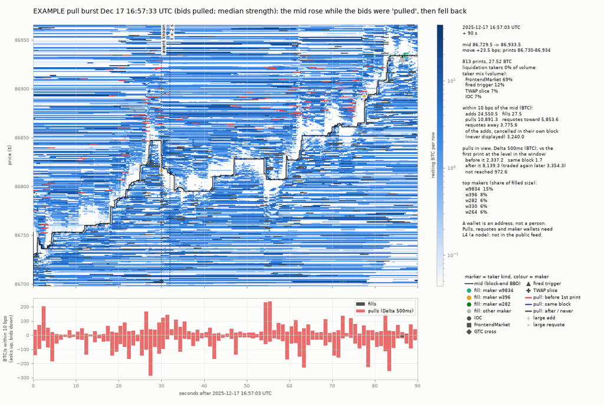

**What to look at:** the bottom panel's tall red bar *below* zero at ~27 s: bids within 10 bps of the mid being pulled, about 3 s before the event is known (t, the 30 s line). A bid-side pull 'points' down, yet over those seconds the mid in the upper panel is **rising**, away from those bids: the section's typical case (52% of events), where the side that 'pulled' is the one price had just left, which reads as quotes being re-set after a move. Right after t the mid falls back 3.9 bps in 5 s (in the burst's direction); over the minute from t + 2 s it moved -12.7 bps in the burst's direction (7th percentile of the family). One event: the family's average beyond comparable seconds is +0.20 bps.

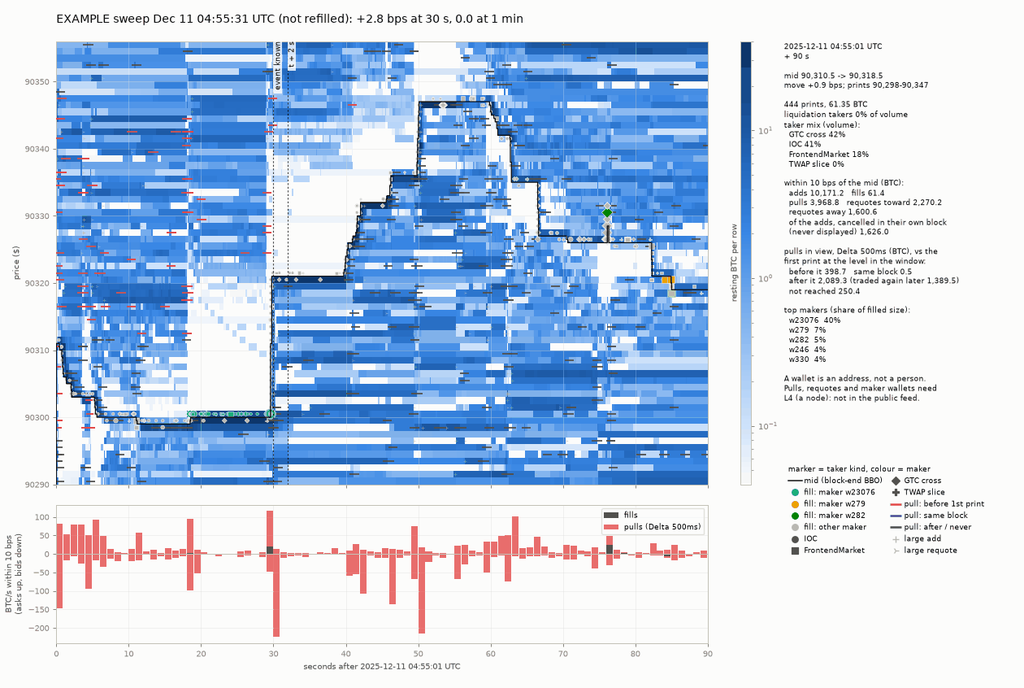

**What to look at:** the swept side stays thin after the sweep, the price edges on for half a minute, and by one minute the gain is gone.

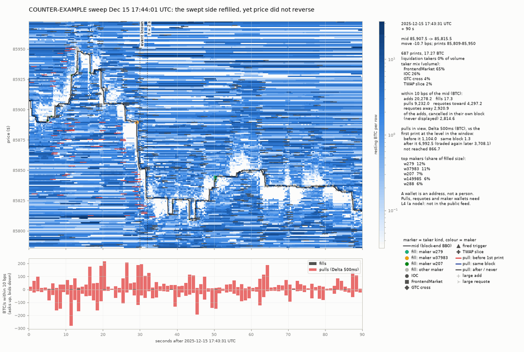

**What to look at:** the swept side fills back in (the 'refilled' read, which on average came with a small give-back), yet price did not reverse: +0.1 bps at 30 s and +1.4 bps over the minute from t + 2 s, in the sweep's direction.

**Observation.** Pull bursts: in 52% [47–55] of events the mid moved *against* the burst's direction while the pulls were being counted, then snapped back; beyond comparable seconds +0.20 [+0.06, +0.36] bps over the minute from t + 2 s. Sweeps: +0.07 bps in the first second, -0.24 [-0.74, +0.21] over the minute from t + 2 s; the refill contrast is real only in the first second (+0.48 if the swept side did not refill, -0.41 if it did), largely the spread closing; from t + 2 s: 0.00 vs -0.39 [-1.01, +0.11].

**Interpretation.** A 'pull burst' here is mostly **quotes being re-set after a move**; the labels used cannot tell that apart from liquidity leaving ahead of a move. The sweep-refill read is gone within ~2 s.

**Class.** Pull labels: **B-L4**. Sweeps and refill: **A**.

```python
PB = {c["name"]: c for c in BN["pull"]["cards"]}["pull_e3"]      # the section's median-strength pull burst
q6_card(PB["t_utc"], "EXAMPLE pull burst Dec 17 16:57:33 UTC (bids pulled; median strength): the mid rose while "
        "the bids were 'pulled', then fell back",
        f"**What to look at:** the bottom panel's tall red bar *below* zero at ~27 s: bids within 10 bps of "
        f"the mid being pulled, about 3 s before the event is known (t, the 30 s line). A bid-side pull 'points' "
        f"down, yet over those seconds the mid in the upper panel is **rising**, away from those bids: the "
        f"section's typical case (52% of events), where the side that 'pulled' is the one price had just left, "
        f"which reads as quotes being re-set after a move. Right after t the mid falls back "
        f"{PB['R_d0_H5']:.1f} bps in 5 s (in the burst's direction); over the minute from t + 2 s it moved "
        f"{PB['R_d2_H60']:+.1f} bps in the burst's direction ({PB['pctl_R_d2_H60']:.0f}th percentile of the "
        f"family). One event: the family's average beyond comparable seconds is +0.20 bps.")
q6_card("2025-12-11 04:55:31", "EXAMPLE sweep Dec 11 04:55:31 UTC (not refilled): +2.8 bps at 30 s, 0.0 at 1 min",
        "**What to look at:** the swept side stays thin after the sweep, the price edges on for half a minute, "
        "and by one minute the gain is gone.")
q6_card("2025-12-15 17:44:01", "COUNTER-EXAMPLE sweep Dec 15 17:44:01 UTC: the swept side refilled, yet price did not reverse",
        "**What to look at:** the swept side fills back in (the 'refilled' read, which on average came with a small "
        "give-back), yet price did not reverse: +0.1 bps at 30 s and +1.4 bps over the minute from t + 2 s, in "
        "the sweep's direction.")
note("Pull bursts: in 52% [47–55] of events the mid moved *against* the burst's direction while the pulls were "
     "being counted, then snapped back; beyond comparable seconds +0.20 [+0.06, +0.36] bps over the minute from "
     "t + 2 s. Sweeps: +0.07 bps in the first second, -0.24 [-0.74, +0.21] over the minute from t + 2 s; the "
     "refill contrast is real only in the first second (+0.48 if the swept side did not refill, -0.41 if it "
     "did), largely the spread closing; from t + 2 s: 0.00 vs -0.39 [-1.01, +0.11].",
     "A 'pull burst' here is mostly **quotes being re-set after a move**; the labels used cannot tell that "
     "apart from liquidity leaving ahead of a move. The sweep-refill read is gone within ~2 s.",
     "Pull labels: **B-L4**. Sweeps and refill: **A**.")
```

#### 6.3 After a manual delay and a taker round trip, every family loses the fee

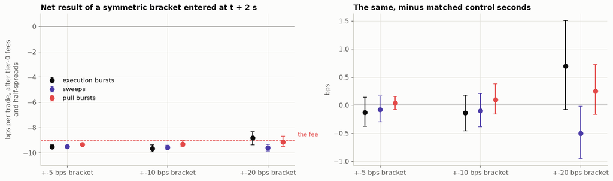

```
hit +X before -X at t + 2 s, +-10 bps: execution bursts 48% vs 47%; sweeps 48% vs 47%; pull bursts 49% vs 46%
```

**Observation.** A symmetric bracket (+-5, +-10 or +-20 bps) entered at t + 2 s resolves within a few points of 50/50 in every family, close to its controls. Net of tier-0 fees and half-spreads it loses about 9–10 bps everywhere. Beyond controls the net is within +-0.35 bps of zero, apart from two marginal +-20 bps cells of opposite sign.

**Interpretation.** None of these book or tape events is an entry trigger on its own at 2–5 s. They tell you a move is happening **now**, not that it will continue.

**Class.** **A** inputs.

```python
fig, axs = plt.subplots(1, 2, figsize=(13.5, 3.9))
Xs = [5, 10, 20]
for j, (f, lab, col) in enumerate(fams):
    fp = Q67["q6"][f]["groups"]["all"]["fp"]
    tri = np.array([est(fp[f"d2_X{X}"]["net_bracket_bps"]) for X in Xs])
    axs[0].errorbar(np.arange(3) + (j - 1) * 0.15, tri[:, 0], yerr=[tri[:, 0] - tri[:, 1], tri[:, 2] - tri[:, 0]],
                    fmt="o", ms=7, color=col, ecolor=col, capsize=3, label=lab)
    trc = np.array([est(fp[f"d2_X{X}"]["net_minus_control_bps"]) for X in Xs])
    axs[1].errorbar(np.arange(3) + (j - 1) * 0.15, trc[:, 0], yerr=[trc[:, 0] - trc[:, 1], trc[:, 2] - trc[:, 0]],
                    fmt="o", ms=7, color=col, ecolor=col, capsize=3, label=lab)
axs[0].axhline(0, color=C["ink2"], lw=1)
axs[0].axhline(-9, color=C["pulled"], lw=1, ls="--")
axs[0].text(2.3, -8.7, "the fee", color=C["pulled"], fontsize=9)
axs[0].set_ylim(-11, 1)
axs[0].set_title("Net result of a symmetric bracket entered at t + 2 s")
axs[0].set_ylabel("bps per trade, after tier-0 fees\nand half-spreads")
axs[1].axhline(0, color=C["ink2"], lw=1)
axs[1].set_title("The same, minus matched control seconds")
axs[1].set_ylabel("bps")
for ax in axs:
    ax.set_xticks(range(3), [f"+-{X} bps bracket" for X in Xs])
axs[0].legend(loc="center left")
plt.show()
print("hit +X before -X at t + 2 s, +-10 bps: " + "; ".join(
    f"{lab} {100 * Q67['q6'][f]['groups']['all']['fp']['d2_X10']['p_plus']['rate']:.0f}% vs "
    f"{100 * Q67['q6'][f]['groups']['all']['fp']['d2_X10']['p_minus']['rate']:.0f}%" for f, lab, _ in fams))
note("A symmetric bracket (+-5, +-10 or +-20 bps) entered at t + 2 s resolves within a few points of 50/50 in "
     "every family, close to its controls. Net of tier-0 fees and half-spreads it loses about 9–10 bps "
     "everywhere. Beyond controls the net is within +-0.35 bps of zero, apart from two marginal +-20 bps cells "
     "of opposite sign.",
     "None of these book or tape events is an entry trigger on its own at 2–5 s. They tell you a move is "
     "happening **now**, not that it will continue.",
     "**A** inputs.")
```

### Q7: Other patterns

#### 7.1 Flicker: about half the near-touch orders live under 500 ms

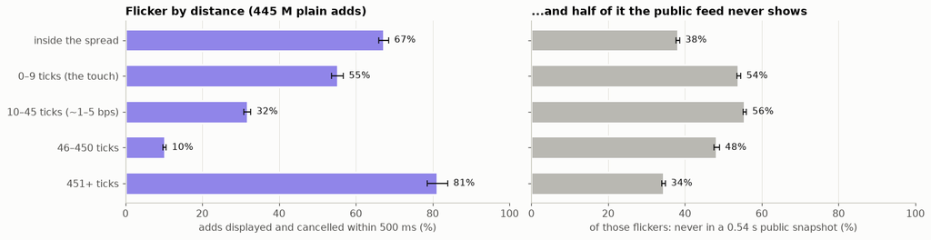

```
near-touch (inside to ~5 bps): 49.1% [47.5–50.2] flickered; fully filled 1.4% [1.3–1.5]. After a >= 5 bps move, flicker per add: up moves: in front 50% / behind 48%; down moves: in front 49% / behind 48%.
```

```python
FL = Q67["q7"]["flicker"]
bands = [("inside", "inside the spread"), ("0-9", "0–9 ticks (the touch)"), ("10-45", "10–45 ticks (~1–5 bps)"),
         ("46-450", "46–450 ticks"), ("451+", "451+ ticks")]
fig, axs = plt.subplots(1, 2, figsize=(13.5, 3.4), sharey=True)
ci_bars(axs[0], [b[1] for b in bands], [est(FL["by_band"][k]["flicker_share"]) for k, _ in bands], C["near"],
        xlim=(0, 100), xlabel="adds displayed and cancelled within 500 ms (%)")
axs[0].set_title(f"Flicker by distance ({FL['all_bands']['adds'] / 1e6:,.0f} M plain adds)")
ci_bars(axs[1], [b[1] for b in bands], [est(FL["by_band"][k]["subsnap_share_of_flicker"]) for k, _ in bands],
        C["added"], xlim=(0, 100), xlabel="of those flickers: never in a 0.54 s public snapshot (%)")
axs[1].set_title("...and half of it the public feed never shows")
plt.show()
dr = FL["directional"]
print(f"near-touch (inside to ~5 bps): {fmt(est(FL['near_touch_0_45']['flicker_share']), d=1)} flickered; "
      f"fully filled {fmt(est(FL['near_touch_0_45']['filled_full_share']), d=1)}. After a >= 5 bps move, flicker per add: "
      f"up moves: in front {100 * est(dr['up']['front_flicker_per_add'])[0]:.0f}% / behind "
      f"{100 * est(dr['up']['behind_flicker_per_add'])[0]:.0f}%; down moves: in front "
      f"{100 * est(dr['down']['front_flicker_per_add'])[0]:.0f}% / behind {100 * est(dr['down']['behind_flicker_per_add'])[0]:.0f}%.")
```

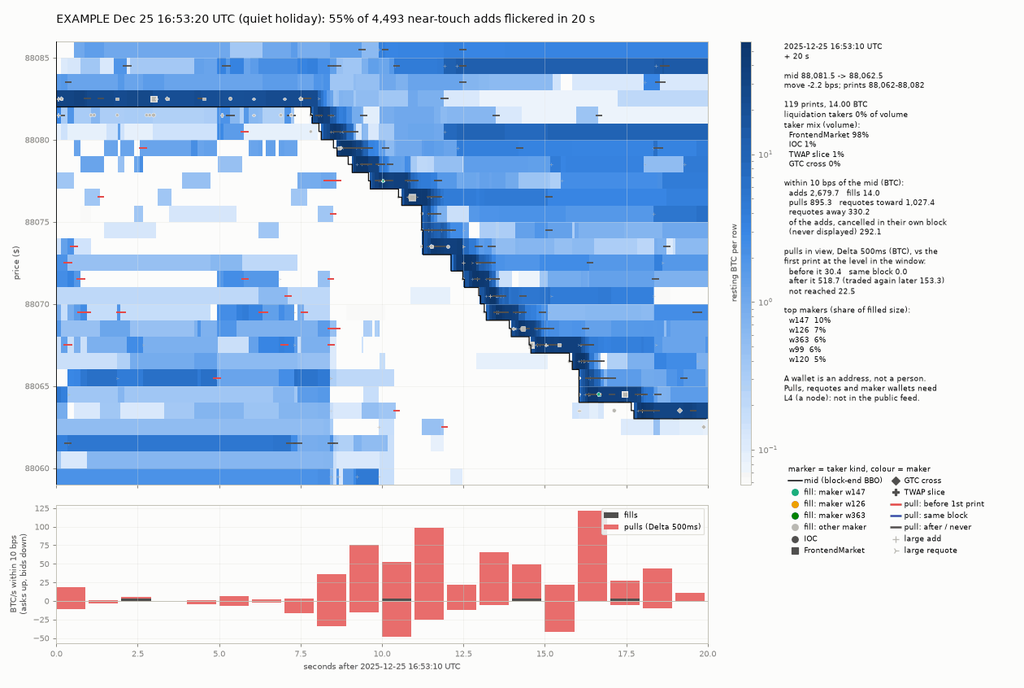

**What to look at:** the gray add/requote marks and short-lived speckle near the mid: most of what the touch 'shows' lives for a fraction of a second.

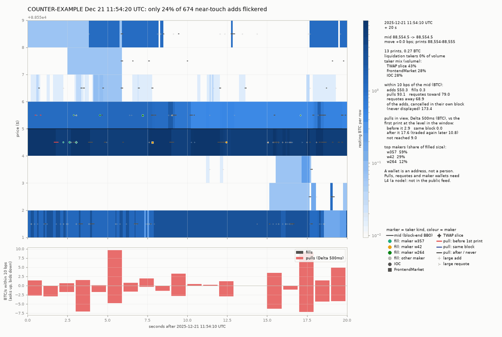

**What to look at:** a calmer, steadier near-touch book with far fewer adds.

**Interpretation.** Displayed size at the touch is 'what the quoting algorithms show this half-second'. The rise after a move is symmetric, so on this data it signals activity, not direction.

**Class.** **B-L4**. The sub-snapshot part is invisible in the public feed by definition.

```python
t = T("2025-12-25 16:53:20")
render_card(t - 10 * NS, t + 10 * NS, title="EXAMPLE Dec 25 16:53:20 UTC (quiet holiday): 55% of 4,493 near-touch adds flickered in 20 s",
            caption="**What to look at:** the gray add/requote marks and short-lived speckle near the mid: most of "
                    "what the touch 'shows' lives for a fraction of a second.")
t = T("2025-12-21 11:54:20")
render_card(t - 10 * NS, t + 10 * NS, title="COUNTER-EXAMPLE Dec 21 11:54:20 UTC: only 24% of 674 near-touch adds flickered",
            caption="**What to look at:** a calmer, steadier near-touch book with far fewer adds.")
note("Of adds from inside the spread to ~5 bps away, 49.1% [47.5–50.2] were displayed and cancelled within "
     "500 ms (at the touch itself, <= 9 ticks: 58.4% [56.8–59.6]). About half of those (49.3%) never appear in a "
     "single 0.54 s public snapshot. Only 1.4% of near-touch adds were fully filled. The top 10 flickering "
     "addresses make 41% of a day's flickers. After a >= 5 bps move, flicker rises on both sides (43% → ~49%).",
     "Displayed size at the touch is 'what the quoting algorithms show this half-second'. The rise after a move "
     "is symmetric, so on this data it signals activity, not direction.",
     "**B-L4**. The sub-snapshot part is invisible in the public feed by definition.")
```

[output not shown]

#### 7.2 A level that "blinks" in the public book is only slightly less dependable

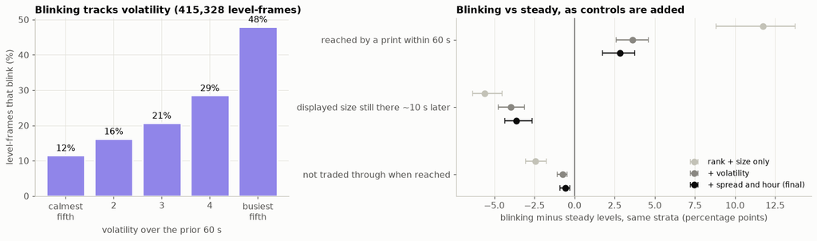

```python
BK_ = Q67["q7"]["blink"]
fig, axs = plt.subplots(1, 2, figsize=(13.5, 3.9), gridspec_kw={"width_ratios": [1, 1.4]})
q = BK_["by_rv60_quintile"]
axs[0].bar(range(5), [100 * q[str(i)]["blink_share"] for i in range(5)], color=C["near"], edgecolor=C["surface"], lw=2)
for i in range(5):
    axs[0].text(i, 100 * q[str(i)]["blink_share"] + 1.2, f"{100 * q[str(i)]['blink_share']:.0f}%", ha="center")
axs[0].set_xticks(range(5), ["calmest\nfifth", "2", "3", "4", "busiest\nfifth"])
axs[0].set_xlabel("volatility over the prior 60 s")
axs[0].set_ylabel("level-frames that blink (%)")
axs[0].set_title(f"Blinking tracks volatility ({BK_['n']:,} level-frames)")
OU = BK_["outcomes"]
ctrl = [("rank_size", "rank + size only"), ("rank_size_rv60", "+ volatility"),
        ("rank_size_rv60_spread_hour", "+ spread and hour (final)")]
outs = [("reached", "reached by a print within 60 s"), ("persist", "displayed size still there ~10 s later"),
        ("held", "not traded through when reached")]
ax = axs[1]
for j, (ck, cl) in enumerate(ctrl):
    tri = np.array([est(OU[o][ck]) for o, _ in outs]) * 100
    ax.errorbar(tri[:, 0], np.arange(3) + (j - 1) * 0.2, xerr=[tri[:, 0] - tri[:, 1], tri[:, 2] - tri[:, 0]],
                fmt="o", ms=7, capsize=3, color=[C["random"], C["muted"], C["ink"]][j], label=cl)
ax.axvline(0, color=C["ink2"], lw=1)
ax.set_yticks(range(3), [o[1] for o in outs])
ax.invert_yaxis()
ax.grid(axis="y", visible=False)
ax.set_xlabel("blinking minus steady levels, same strata (percentage points)")
ax.legend(loc="lower right", fontsize=9)
ax.set_title("Blinking vs steady, as controls are added")
plt.show()
```

> **What changed after the skeptic review.** The first version said blinking levels were **"reached 12 pp more often"**, which looked like a cue that a level was about to be hit. That was mostly **volatility**: blinking is 12% of frames in the calmest fifth and 48% in the busiest, and busy markets reach more levels. Within the same volatility, spread and hour the difference is **+2.8 pp** (the right-hand chart shows it shrink as each control is added).

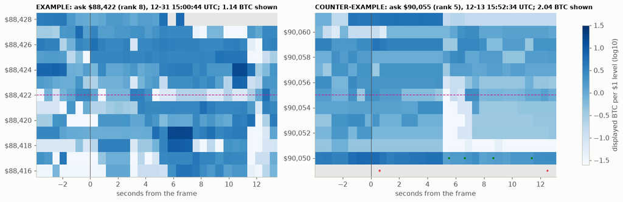

**What to look at:** each column is one public `l2Book` frame (~0.54 s); gray = outside the 20 displayed levels; dots are the public prints (green = buy aggressor, red = sell). Left, the level's size switches on and off frame to frame (blinking); right, a blinking level whose 2.04 BTC nevertheless persisted.

**Observation.** 25% of level-frames blink (>= 3 size changes of >= 50% in 6 public snapshots; 415,328 level-frames, 3 sampled hours x 16 days). Blinking tracks volatility: 12% of frames in the calmest fifth, 48% in the busiest. Blinking vs steady, within the same volatility, spread and hour: displayed size still there ~10 s later -3.6 pp [-4.3, -2.6]; reached by a print within 60 s +2.8 pp [+1.8, +3.8]; NOT traded through when reached -0.6 pp [-0.9, -0.3], i.e. traded through 0.6 pp more often.

**Interpretation.** Blinking size is quote churn, a little less dependable as displayed size. It does not mark a level that will break.

**Class.** **A** (the 20-level feed).

```python
def blink_strip(ax, t, side, px_usd, title):
    """The emulated December l2Book (20 levels, $1 grid, ~0.54 s) around one level, frame by frame, with the
    public prints: exactly what a trader could see (class A)."""
    t0, t1 = t - 4 * NS, t + 13 * NS
    assert_odd_window(t0, t1)
    fr = EM.l2_snapshots(DERIVED, t0, t1, n_sig_figs=5)
    fr = fr[fr.side == side].assign(slot=lambda d: d.px.to_numpy(np.int64) // 10)
    times = np.sort(fr.t.unique())
    L = int(px_usd)
    M = np.full((13, times.size), np.nan)
    ti = np.searchsorted(times, fr.t.to_numpy())
    for i in range(times.size):
        f = fr[ti == i]
        if len(f):                                   # inside the displayed range but absent = 0 (white)
            for sl in range(max(f.slot.min(), L - 6), min(f.slot.max(), L + 6) + 1):
                M[sl - (L - 6), i] = 0.0
    keep = (fr.slot >= L - 6) & (fr.slot <= L + 6)
    M[fr.slot.to_numpy()[keep] - (L - 6), ti[keep]] = fr.sz.to_numpy()[keep] / 1e5
    xs = (times - t) / 1e9
    cmap = plt.get_cmap("Blues").copy()
    cmap.set_bad("#e6e6e6")
    pc = ax.pcolormesh(np.r_[xs, xs[-1] + 0.54], np.arange(L - 6, L + 8) - 0.5,
                       np.ma.masked_invalid(np.log10(M + 0.03)), cmap=cmap, vmin=-1.6, vmax=1.5, shading="flat")
    tr = read_window("tradesx", ["ts", "px", "aggr_is_ask"], t0, t1)
    ax.scatter((tr.ts - t) / 1e9, tr.px / 10, s=10, c=np.where(tr.aggr_is_ask, C["down"], C["up"]), lw=0, zorder=3)
    ax.axhline(L, color=C["hilite"], lw=1, ls="--")
    ax.axvline(0, color=C["ink2"], lw=0.8)
    ax.set_ylim(L - 6.5, L + 6.5)
    ax.yaxis.set_major_formatter(lambda v, _: f"${v:,.0f}")
    ax.set_xlabel("seconds from the frame")
    ax.set_title(esc(title), fontsize=10)
    N_LIVE["feeds"] += 1
    return pc


CB = [c for c in BN["blink"]["cards"] if c["t_utc"][:10] in ("2025-12-31", "2025-12-13")]
if RENDER_LIVE:
    fig, axs = plt.subplots(1, 2, figsize=(13.5, 4.3))
    for ax, c in zip(axs, sorted(CB, key=lambda c: c["role"] != "example")):
        odd_day(c["t_utc"][:10].replace("-", ""))
        role = "EXAMPLE" if c["role"] == "example" else "COUNTER-EXAMPLE"
        pc = blink_strip(ax, int(c["t"]), int(c["side"]), c["px"],
                         f"{role}: {'bid' if c['side'] == 0 else 'ask'} ${c['px']:,} (rank {c['rank']}), "
                         f"{c['t_utc'][5:19]} UTC; {c['sz_btc']:.2f} BTC shown")
    fig.colorbar(pc, ax=axs, label="displayed BTC per $1 level (log10)", shrink=0.85)
    plt.show()
    display(Markdown("**What to look at:** each column is one public `l2Book` frame (~0.54 s); gray = outside "
                     "the 20 displayed levels; dots are the public prints (green = buy aggressor, red = sell). "
                     "Left, the level's size switches on and off frame to frame (blinking); right, a blinking "
                     "level whose 2.04 BTC nevertheless persisted."))
note("25% of level-frames blink (>= 3 size changes of >= 50% in 6 public snapshots; 415,328 level-frames, 3 "
     "sampled hours x 16 days). Blinking tracks volatility: 12% of frames in the calmest fifth, 48% in the "
     "busiest. Blinking vs steady, within the same volatility, spread and hour: displayed size still there "
     "~10 s later -3.6 pp [-4.3, -2.6]; reached by a print within 60 s +2.8 pp [+1.8, +3.8]; NOT traded "
     "through when reached -0.6 pp [-0.9, -0.3], i.e. traded through 0.6 pp more often.",
     "Blinking size is quote churn, a little less dependable as displayed size. It does not mark a level that "
     "will break.",
     "**A** (the 20-level feed).")
```

#### 7.3 Round numbers and "third time lucky" are not special on this data

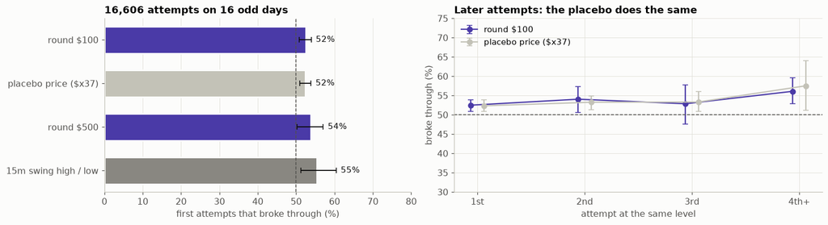

```python
AT = Q67["q7"]["attempts"]["by_family"]
fams7 = [("R100", "round $100", C["failed"]), ("P37", "placebo price ($x37)", C["random"]),
         ("R500", "round $500", C["failed"]), ("SW15", "15m swing high / low", C["muted"])]
fig, axs = plt.subplots(1, 2, figsize=(13.5, 3.6), gridspec_kw={"width_ratios": [1, 1.2]})
ci_bars(axs[0], [f[1] for f in fams7], [est(AT[k]["by_k"]["1"]["broke_through"]) for k, _, _ in fams7],
        [f[2] for f in fams7], xlim=(0, 80), ref=50, xlabel="first attempts that broke through (%)")
axs[0].set_title(f"{Q67['q7']['attempts']['n']:,} attempts on 16 odd days")
ax = axs[1]
ks = ["1", "2", "3", "4+"]
for j, (k, lab, col) in enumerate(fams7[:2]):
    tri = np.array([est(AT[k]["by_k"][kk]["broke_through"]) for kk in ks if kk in AT[k]["by_k"]]) * 100
    xx = np.arange(len(tri)) + (j - 0.5) * 0.12
    ax.errorbar(xx, tri[:, 0], yerr=[tri[:, 0] - tri[:, 1], tri[:, 2] - tri[:, 0]], fmt="o-", ms=6, color=col,
                ecolor=col, capsize=3, label=lab)
ax.axhline(50, color=C["ink2"], lw=1, ls="--")
ax.set_xticks(range(4), ["1st", "2nd", "3rd", "4th+"])
ax.set_xlabel("attempt at the same level")
ax.set_ylabel("broke through (%)")
ax.set_ylim(30, 75)
ax.legend(loc="upper left")
ax.set_title("Later attempts: the placebo does the same")
plt.show()
```

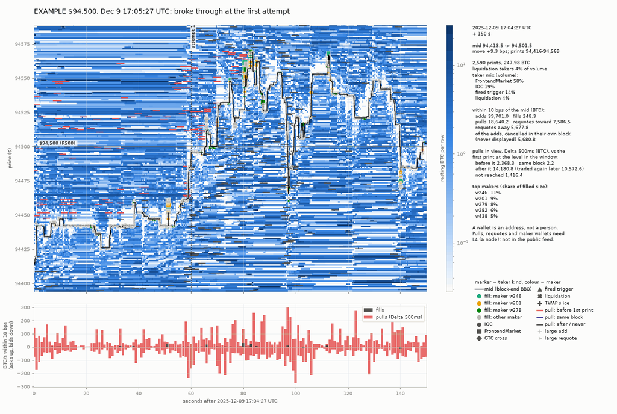

**What to look at:** price reaches the round number once and goes straight through.

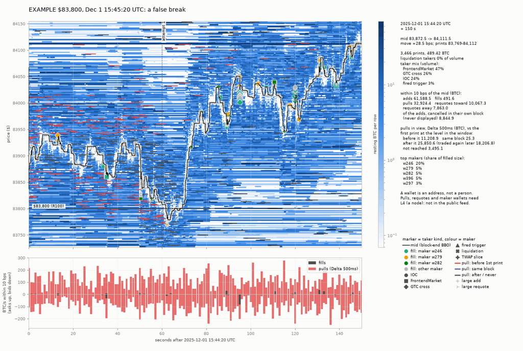

**What to look at:** a poke through the level and a return: the *usual* way an attempt is rejected (60–73% of rejections).

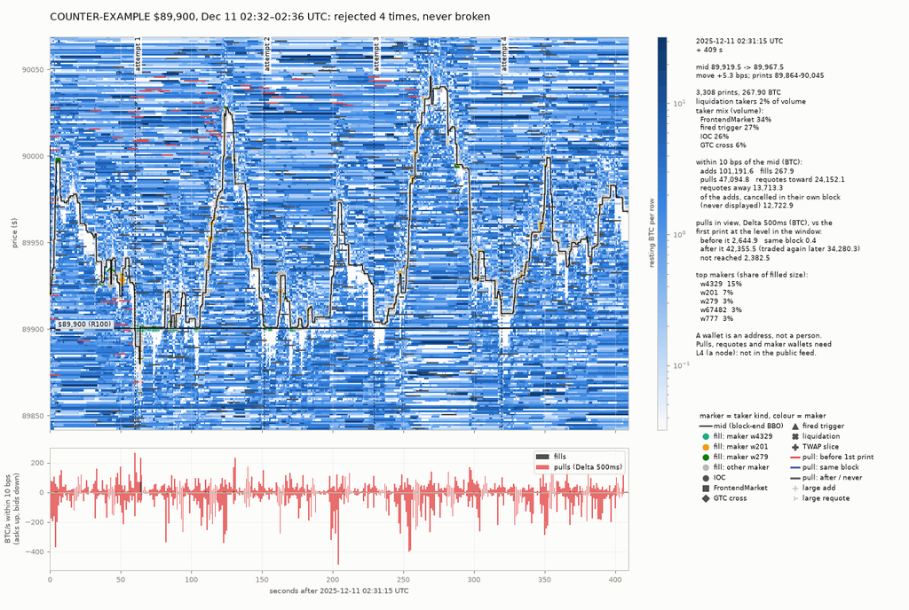

**What to look at:** four approaches, four rejections: what a trader would call a 'real level'. It is one draw from a pattern the placebo price reproduces.

**Observation.** First-attempt break-through rates (16,606 attempts, 16 days): round $100 52.5% [50.9–53.9], placebo price ($x37) 52.3% [50.9–53.9], round $500 54%, 15m swing high/low 55%. Later attempts differ by a few points, inside the CIs, and the placebo shows the same pattern. A poke >= $2 through the level followed by a return is the usual way an attempt is rejected (60–73% of rejections). A +-10 bps bracket after a poke nets -9.2 to -9.8 bps.

**Interpretation.** A round number behaves like any other price. A poke through it is weak evidence either way.

**Class.** Prints: **A**. Whether an attempt broke through: **C**.

```python
CA = {c["name"]: c for c in BN["attempts"]["cards"]}


def attempts_card(name, title, caption):
    c = CA[name]
    st = [T(a["start_utc"]) for a in c["attempt_list"]]
    t0, t1 = min(st) - 60 * NS, max(st) + 90 * NS
    lo, hi = price_range(t0, t1, include=[c["level"]], pad_frac=0.12)
    return render_card(t0, t1, lo, hi, title=title, hlines=[(c["level"], f"${c['level']:,.0f} ({c['family']})")],
                       vlines=[(s, f"attempt {i + 1}") for i, s in enumerate(st)], caption=caption)


attempts_card("attempts_e1", "EXAMPLE $94,500, Dec 9 17:05:27 UTC: broke through at the first attempt",
              "**What to look at:** price reaches the round number once and goes straight through.")
attempts_card("attempts_e3", "EXAMPLE $83,800, Dec 1 15:45:20 UTC: a false break",
              "**What to look at:** a poke through the level and a return: the *usual* way an attempt is "
              "rejected (60–73% of rejections).")
attempts_card("attempts_c2", "COUNTER-EXAMPLE $89,900, Dec 11 02:32–02:36 UTC: rejected 4 times, never broken",
              "**What to look at:** four approaches, four rejections: what a trader would call a 'real level'. It "
              "is one draw from a pattern the placebo price reproduces.")
note("First-attempt break-through rates (16,606 attempts, 16 days): round $100 52.5% [50.9–53.9], placebo price "
     "($x37) 52.3% [50.9–53.9], round $500 54%, 15m swing high/low 55%. Later attempts differ by a few points, "
     "inside the CIs, and the placebo shows the same pattern. A poke >= $2 through the level followed by a return "
     "is the usual way an attempt is rejected (60–73% of rejections). A +-10 bps bracket after a poke nets -9.2 "
     "to -9.8 bps.",
     "A round number behaves like any other price. A poke through it is weak evidence either way.",
     "Prints: **A**. Whether an attempt broke through: **C**.")
```

#### 7.4 Around fast moves the taker side turns mechanical, and makers re-quote harder rather than leave

**Where "the start" sits here.** This section detects its 119 moves itself (the pre-registered rule, METHODOLOGY §3.9) and times every window from the **detection point** t: the first 100 ms at which the mid is ≥ 20 bps away from its own trailing 30 s mean. At t price is therefore already well off its recent average, so part of the jump happens *before* t (on the Dec 19 20:35:49 card below it starts ~3 s earlier), and the "−30 to 0 s (onset)" window can contain the first seconds of the jump itself. Its 26% is not purely flow *ahead* of the move. (Q1/Q3 instead back-date its "move starts" to where the run began.)

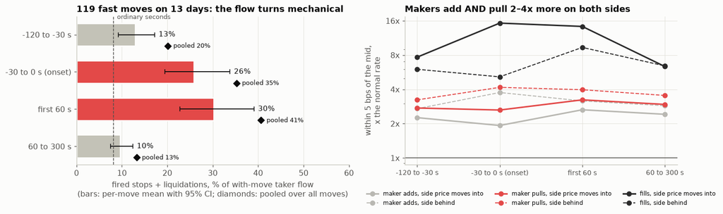

```python
MX = Q67["q7"]["mix"]
wins = ["pre (-120..-30 s)", "onset (-30..0 s)", "first 60 s", "60-300 s"]
wlab = ["-120 to -30 s", "-30 to 0 s (onset)", "first 60 s", "60 to 300 s"]
base = MX["baseline_kind_share"]["fired trigger"] + MX["baseline_kind_share"]["liquidation"]
fig, axs = plt.subplots(1, 2, figsize=(13.5, 3.9))
ci_bars(axs[0], wlab, [est(MX["windows"][w]["liqtrig_share_of_with_flow"]) for w in wins],
        [C["random"], C["pulled"], C["pulled"], C["random"]], xlim=(0, 60), ref=100 * base,
        xlabel="fired stops + liquidations, % of with-move taker flow")
pooled = [100 * (MX["windows"][w]["with_kind_share"]["fired trigger"] + MX["windows"][w]["with_kind_share"]["liquidation"])
          for w in wins]
axs[0].scatter(pooled, np.arange(4) + 0.3, marker="D", s=40, color=C["ink"], zorder=5)
for yi, v in enumerate(pooled):
    axs[0].text(v + 1.2, yi + 0.3, f"pooled {v:.0f}%", va="center", fontsize=8.5, color=C["ink"])
axs[0].text(100 * base + 0.8, -0.42, "ordinary seconds", fontsize=8.5, color=C["ink2"])
axs[0].set_xlabel("fired stops + liquidations, % of with-move taker flow\n"
                  "(bars: per-move mean with 95% CI; diamonds: pooled over all moves)")
axs[0].set_title(f"{MX['episodes']} fast moves on {MX['days']} days: the flow turns mechanical")
ax = axs[1]
for key, lab, col in (("adds", "maker adds", C["added"]), ("pulls", "maker pulls", C["pulled"]),
                      ("fills", "fills", C["filled"])):
    for side, ls in (("target", "-"), ("opposite", "--")):
        v = [MX["passive"][w][f"{side}_{key}"] for w in wins]
        ax.plot(range(4), v, ls, marker="o", color=col, lw=2 if side == "target" else 1.3,
                label=f"{lab}, {'side price moves into' if side == 'target' else 'side behind'}")
ax.axhline(1, color=C["ink2"], lw=1)
ax.set_yscale("log")
ax.set_yticks([1, 2, 4, 8, 16], ["1x", "2x", "4x", "8x", "16x"])
ax.set_xticks(range(4), wlab, fontsize=9)
ax.set_ylabel("within 5 bps of the mid,\nx the normal rate")
ax.legend(fontsize=8, ncol=3, loc="upper center", bbox_to_anchor=(0.5, -0.14))
ax.set_title("Makers add AND pull 2–4x more on both sides")
plt.show()
```

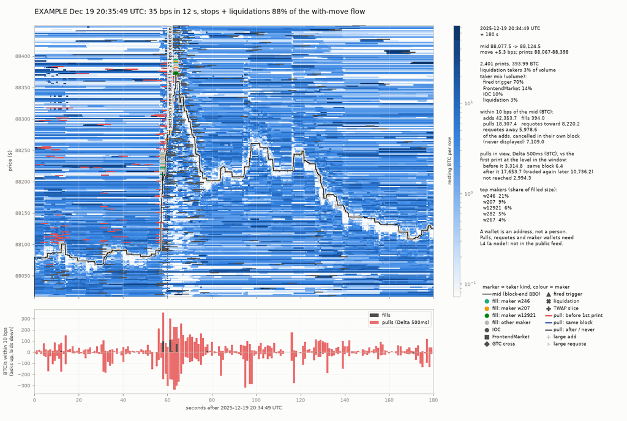

**What to look at:** the move is carried almost entirely by triangles (fired stops) and X's (liquidations). Note that the jump, and the first triangles, begin 2–3 s **before** the detection line (the mid leaves ~$88,090 at about 20:35:46.5): the section's '30 s before the start' window includes them.

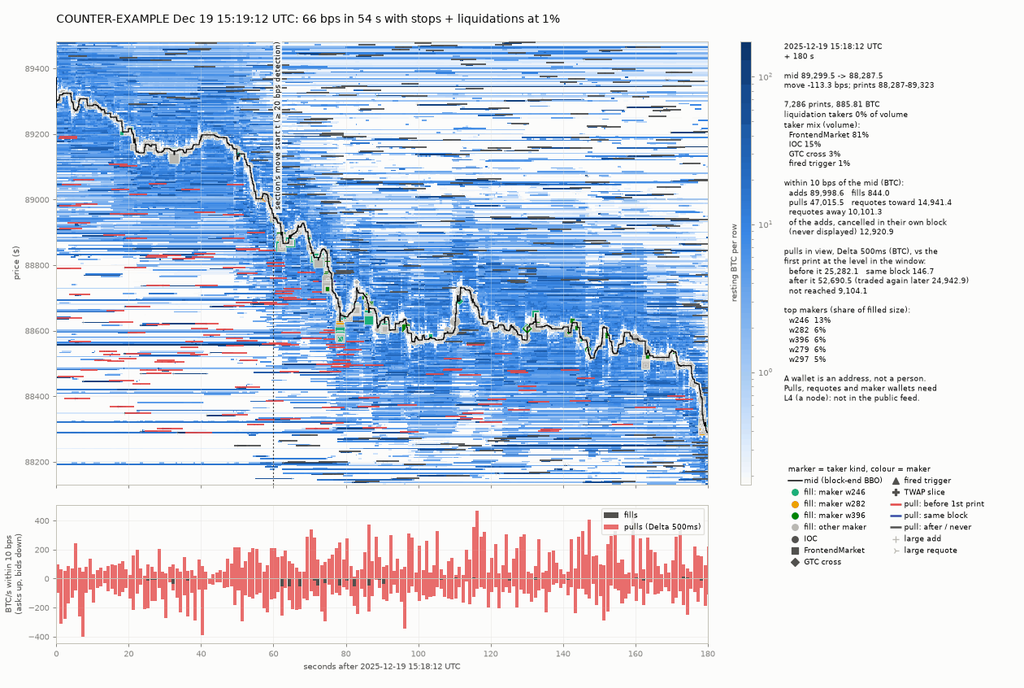

**What to look at:** a large fast move carried by ordinary orders: almost no triangles or X's.

**Observation.** 119 fast moves on 13 days (a separate detection from Q1/Q3). Fired stops + liquidations as a share of with-move taker flow: 26% in the 30 s before the start, 41% in the first 60 s, ~8% in ordinary seconds (in the chart: 26% is the per-move mean of the onset window, 41% the pooled share of the first 60 s). The 'start' is the detection point, so the −30..0 s window can include the first seconds of the jump. Within 5 bps of the mid, makers add and pull 2–4x their usual volume on both sides, while fills run 6–15x normal.

**Interpretation.** Gross turnover rises on both sides. That is compatible with 1.4, where the net size at the exact levels a sweep crosses is small when it gets there: the book is re-quoted hard *and* thin just ahead of the sweep.

**Class.** Taker kind: **B-L4**. Total flow and aggressor side: **A**.

```python
for tt, title, cap in (("2025-12-19 20:35:49.3", "EXAMPLE Dec 19 20:35:49 UTC: 35 bps in 12 s, stops + liquidations 88% of the with-move flow",
                        "**What to look at:** the move is carried almost entirely by triangles (fired stops) and "
                        "X's (liquidations). Note that the jump, and the first triangles, begin 2–3 s **before** the "
                        "detection line (the mid leaves ~$88,090 at about 20:35:46.5): the section's '30 s before the "
                        "start' window includes them."),
                       ("2025-12-19 15:19:12.1", "COUNTER-EXAMPLE Dec 19 15:19:12 UTC: 66 bps in 54 s with stops + liquidations at 1%",
                        "**What to look at:** a large fast move carried by ordinary orders: almost no triangles or X's.")):
    t = T(tt)
    render_card(t - 60 * NS, t + 120 * NS, title=title,
                vlines=[(t, "section's move start t (≥ 20 bps detection)")], caption=cap)
note("119 fast moves on 13 days (a separate detection from Q1/Q3). Fired stops + liquidations as a share of "
     "with-move taker flow: 26% in the 30 s before the start, 41% in the first 60 s, ~8% in ordinary seconds "
     "(in the chart: 26% is the per-move mean of the onset window, 41% the pooled share of the first 60 s). "
     "The 'start' is the detection point, so the −30..0 s window can include the first seconds of the jump. "
     "Within 5 bps of the mid, makers add and pull 2–4x their usual volume on both sides, while fills run 6–15x "
     "normal.",
     "Gross turnover rises on both sides. That is compatible with 1.4, where the net size at the exact levels a "
     "sweep crosses is small when it gets there: the book is re-quoted hard *and* thin just ahead of the sweep.",
     "Taker kind: **B-L4**. Total flow and aggressor side: **A**.")
```

#### 7.5 Stop cascades come in batches on a ~3 s clock, and stops fill past their trigger

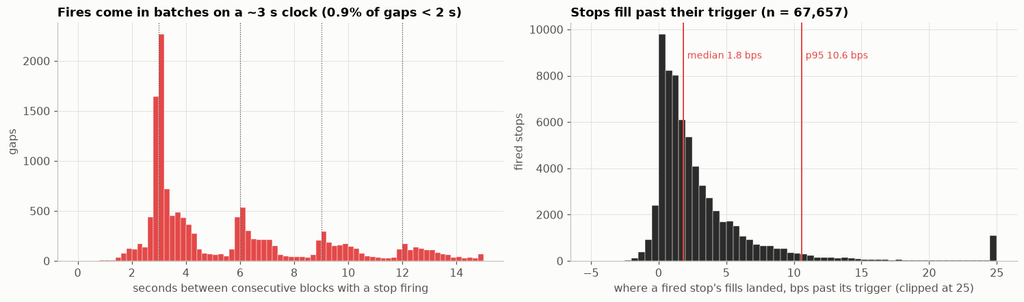

```
re-derived here from the fires table: gaps n = 27,453 (section 27,453); fill past trigger median 1.82 bps (section 1.82), p95 10.6 (section 10.6); mid already 1.5 bps past the trigger at the fire (median).
```

```python
TG = Q67["q7"]["triggers"]
fires = []
for d in ODD_DAYS:
    fires.append(pd.read_parquet(INTERIM / f"q6q7_work/trig_fires_{odd_day(d)}.parquet",
                                 columns=["ts", "dir", "with_travel", "exec_btc", "exec_usd", "trig_usd", "day"]))
TF7 = pd.concat(fires, ignore_index=True)
gaps = np.concatenate([np.diff(np.unique(g.ts.to_numpy(np.int64))) / 1e9 for _, g in TF7.groupby("day")])
ex = TF7[TF7.with_travel & (TF7.exec_btc > 0) & TF7.trig_usd.notna()]
fill_bps = (ex["dir"] * 1e4 * ((ex.exec_usd / ex.exec_btc) / ex.trig_usd - 1)).to_numpy(float)
fig, axs = plt.subplots(1, 2, figsize=(13.5, 3.9))
ax = axs[0]
ax.hist(gaps[gaps < 15], bins=np.arange(0, 15.01, 0.2), color=C["pulled"], edgecolor=C["surface"], lw=0.3)
for s in (3, 6, 9, 12):
    ax.axvline(s, color=C["ink2"], lw=0.8, ls=":")
ax.set_xlabel("seconds between consecutive blocks with a stop firing")
ax.set_ylabel("gaps")
ax.set_title(f"Fires come in batches on a ~3 s clock ({(gaps < 2).mean() * 100:.1f}% of gaps < 2 s)")
ax = axs[1]
ax.hist(np.clip(fill_bps, -5, 25), bins=np.arange(-5, 25.1, 0.5), color=C["filled"], edgecolor=C["surface"], lw=0.3)
for q_, lab in ((50, "median"), (95, "p95")):
    v = np.percentile(fill_bps, q_)
    ax.axvline(v, color=C["pulled"], lw=1.3)
    ax.text(v + 0.3, ax.get_ylim()[1] * 0.85, f"{lab} {v:.1f} bps", color=C["pulled"], fontsize=9)
ax.set_xlabel("where a fired stop's fills landed, bps past its trigger (clipped at 25)")
ax.set_ylabel("fired stops")
ax.set_title(f"Stops fill past their trigger (n = {len(fill_bps):,})")
plt.show()
print(f"re-derived here from the fires table: gaps n = {gaps.size:,} (section {TG['fire_block_gaps_s']['n']:,}); "
      f"fill past trigger median {np.median(fill_bps):.2f} bps (section {TG['fill_past_trigger_bps']['median']:.2f}), "
      f"p95 {np.percentile(fill_bps, 95):.1f} (section {TG['fill_past_trigger_bps']['p95']:.1f}); mid already "
      f"{TG['mid_past_trigger_at_fire_bps']['median']:.1f} bps past the trigger at the fire (median).")
```

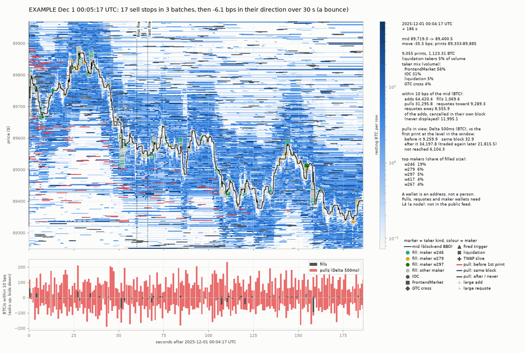

**What to look at:** the triangles arrive in separate batches a few seconds apart (the ~3 s rhythm), each landing a little past its trigger.

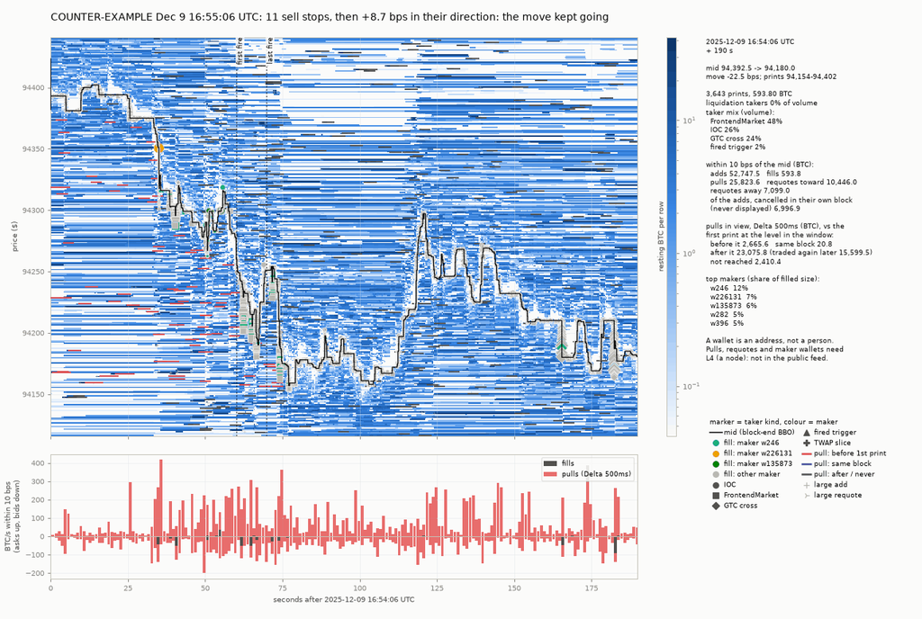

**What to look at:** a sell-stop cascade that did not mark a bottom or a top: price carried on.

**Observation.** 93,207 fired triggers on 16 days. Fires come in same-block batches: only 0.9% of gaps between fire blocks are under 2 s; gaps pile up at 3, 6 and 9 s. At the fire the mid is already a median 1.5 bps past the trigger; the stop's fills land a median 1.8 bps past it (p95 10.6 bps); 4.3% fired and were then rejected. A batch is followed by another within 4 s 24% of the time, against 11% for a moment with the same trailing 3 s move (~2x [2.0–2.4]); once price has already run > 5 bps in 3 s the ratio is ~1x (0.95–1.15). After a cascade of >= 10 fires the mid gives back -1.5 bps within 5 s of the last fire, then ~0 over the minute from t + 2 s.

**Interpretation.** The ~3 s rhythm is consistent with HL's mark-price update cadence (triggers fire on the mark price); that cause is an interpretation, the mark series is not in the warehouse. The clustering is mostly the price path, not 'stop fills as fuel'. What a manual trader can use is the **rhythm and the slippage**.

**Class.** Fire identity and the stop book: **B-L4**. The 3 s pulse of prints is visible on the public tape (**A**), unlabelled.

```python
CC = {c["name"]: c for c in BN["cascade"]["cards"]}
for name, title, cap in (("cascade_e3", "EXAMPLE Dec 1 00:05:17 UTC: 17 sell stops in 3 batches, then -6.1 bps in their direction over 30 s (a bounce)",
                          "**What to look at:** the triangles arrive in separate batches a few seconds apart (the "
                          "~3 s rhythm), each landing a little past its trigger."),
                         ("cascade_c2", "COUNTER-EXAMPLE Dec 9 16:55:06 UTC: 11 sell stops, then +8.7 bps in their direction: the move kept going",
                          "**What to look at:** a sell-stop cascade that did not mark a bottom or a top: price carried on.")):
    c = CC[name]
    a, b = T(c["t_first_utc"]), T(c["t_last_utc"])
    render_card(a - 60 * NS, min(b + 120 * NS, a + 600 * NS), title=title,
                vlines=[(a, "first fire"), (b, "last fire")], caption=cap)
note("93,207 fired triggers on 16 days. Fires come in same-block batches: only 0.9% of gaps between fire blocks "
     "are under 2 s; gaps pile up at 3, 6 and 9 s. At the fire the mid is already a median 1.5 bps past the "
     "trigger; the stop's fills land a median 1.8 bps past it (p95 10.6 bps); 4.3% fired and were then "
     "rejected. A batch is followed by another within 4 s 24% of the time, against 11% for a moment with the "
     "same trailing 3 s move (~2x [2.0–2.4]); once price has already run > 5 bps in 3 s the ratio is ~1x "
     "(0.95–1.15). After a cascade of >= 10 fires the mid gives back -1.5 bps within 5 s of the last fire, "
     "then ~0 over the minute from t + 2 s.",
     "The ~3 s rhythm is consistent with HL's mark-price update cadence (triggers fire on the mark price); that "
     "cause is an interpretation, the mark series is not in the warehouse. The clustering is mostly the price "
     "path, not 'stop fills as fuel'. What a manual trader can use is the **rhythm and the slippage**.",
     "Fire identity and the stop book: **B-L4**. The 3 s pulse of prints is visible on the public tape (**A**), "
     "unlabelled.")
```

## 3. The provisional watch-list for a manual BTC trader

**PROVISIONAL.** Everything above is descriptive, hindsight-aligned evidence from the discovery half. **Descriptive evidence is not support for using any item as a pre-trade signal.** The order ranks items by how consistently the observation held across sections and counter-examples, and by how directly it bears on a manual trader's own orders (sizing, slippage, stop placement). It is **not** a ranking by edge: **no item showed a tradeable edge.** Several items are listed precisely because the data went *against* them.

```python
WLST = pd.DataFrame([
    (1, "Size displayed just ahead of price, especially in a fast market", "l2Book 20 x $1 (~2 bps) and $10 buckets, A",
     "expect far less to be there when price arrives; fills and slippage will be worse than the book suggests",
     "Risk and sizing only. Consistent in Q1/Q3, Q2, Q4 and Q5; not a direction signal"),
    (2, "One-sided tape bursts, sweeps, pokes through round numbers", "trades, bbo, A",
     "the move has already happened", "Against as an entry trigger at 2–5 s: every family nets about -9 bps"),
    (3, "A stop cascade: 3 s pulses of prints", "trades rhythm A; stop identity B-L4; a known address's stops B-addr",
     "stops fill ~1.8 bps past the trigger (p95 ~11); stops + liquidations are ~1/3 of fast-move flow",
     "Execution only (placing your own stops); no direction"),
    (4, "Binance BTC perp moving first", "Binance trades, A", "HL tends to follow within ~0.7 s",
     "Context only: below the manual reaction floor, and the HL event adds nothing"),
    (5, "The minute after a fast move", "$10-bucket book, A", "depth near price stays below normal for ~1 min or more",
     "Sizing only"),
    (6, "A single large order near price", "size and distance A; owner and reduce-only/stop flags B-addr",
     "if price actually gets to it, it usually trades; its pull says nothing about direction; absorption at it is 50/50",
     "Not supported as a hold/defence cue"),
    (7, "Up to 10 top quoter addresses", "orderUpdates, B-addr",
     "a live map of where most near-touch size is and when it leaves", "Liquidity map only; no 'informed maker' found"),
    (8, "Depth and resting stops beyond a range edge; the book at the first stall", "book A; stops B-L4",
     "nothing that separated success from failure", "Against"),
    (9, "Round numbers; repeated attempts", "trades A", "same as a placebo price", "Against"),
    (10, "Blinking levels; flicker; pull bursts", "book A (blink); B-L4 (flicker, pulls)",
     "activity and quote churn, not direction", "Against as direction"),
], columns=["#", "What to watch", "Feed / class", "What it might mean", "Pre-trade support so far"]).set_index("#")


def _support_style(v: str) -> str:
    if v.startswith(("Against", "Not supported")):
        return "background-color:#fbe3e3;color:#7a1f1f;font-weight:600"
    return "background-color:#fdf3dc;color:#5c4400;font-weight:600"


display(WLST.style.map(_support_style, subset=["Pre-trade support so far"])
        .set_properties(**{"text-align": "left", "vertical-align": "top", "font-size": "12.5px"})
        .set_table_styles([{"selector": "th", "props": "text-align:left;background:#f4f3ef;font-size:12.5px"},
                           {"selector": "td", "props": "padding:6px 9px;border-bottom:1px solid #e1e0d9"}])
        .set_caption("Red = the evidence so far is AGAINST using it (or does not support it); amber = usable only "
                     "for sizing, execution or context. Nothing is green: no item showed a tradeable edge."))
```

Red = the evidence so far is AGAINST using it (or does not support it); amber = usable only for sizing, execution or context. Nothing is green: no item showed a tradeable edge.

| # | What to watch | Feed / class | What it might mean | Pre-trade support so far |
| --- | --- | --- | --- | --- |
| 1 | Size displayed just ahead of price, especially in a fast market | l2Book 20 x $1 (~2 bps) and $10 buckets, A | expect far less to be there when price arrives; fills and slippage will be worse than the book suggests | Risk and sizing only. Consistent in Q1/Q3, Q2, Q4 and Q5; not a direction signal |
| 2 | One-sided tape bursts, sweeps, pokes through round numbers | trades, bbo, A | the move has already happened | Against as an entry trigger at 2–5 s: every family nets about -9 bps |
| 3 | A stop cascade: 3 s pulses of prints | trades rhythm A; stop identity B-L4; a known address's stops B-addr | stops fill ~1.8 bps past the trigger (p95 ~11); stops + liquidations are ~1/3 of fast-move flow | Execution only (placing your own stops); no direction |
| 4 | Binance BTC perp moving first | Binance trades, A | HL tends to follow within ~0.7 s | Context only: below the manual reaction floor, and the HL event adds nothing |
| 5 | The minute after a fast move | $10-bucket book, A | depth near price stays below normal for ~1 min or more | Sizing only |
| 6 | A single large order near price | size and distance A; owner and reduce-only/stop flags B-addr | if price actually gets to it, it usually trades; its pull says nothing about direction; absorption at it is 50/50 | Not supported as a hold/defence cue |
| 7 | Up to 10 top quoter addresses | orderUpdates, B-addr | a live map of where most near-touch size is and when it leaves | Liquidity map only; no 'informed maker' found |
| 8 | Depth and resting stops beyond a range edge; the book at the first stall | book A; stops B-L4 | nothing that separated success from failure | Against |
| 9 | Round numbers; repeated attempts | trades A | same as a placebo price | Against |
| 10 | Blinking levels; flicker; pull bursts | book A (blink); B-L4 (flicker, pulls) | activity and quote churn, not direction | Against as direction |

**The two items with the most to say about your own orders:**

- **1. Discount the size you see just ahead of price, most of all in a fast market.** In fast moves only ~1 in 11 traversed levels held ≥ 1 BTC when price arrived (vs ~1 in 2 calm); of the size at a range edge, a median ~9% traded there in the next minute; of orders resting ≥ 3 s that price approached, 9% of the BTC was still there at the print. *Fails when* slow wallets have large bids resting (Dec 7 14:25:58), an edge is actually consumed (Dec 9 20:16:05), or fresh size appears 130 ms before a print (Dec 17 16:15:04). It describes the book *in hindsight* and why the levels were thin is not identified: sizing and slippage expectations only. Confirmatory: H01/H09, H13–H15.
- **3. In a stop cascade, expect 3 s pulses and slippage past the trigger.** Your own stop fills a median 1.8 bps past its trigger (p95 ~11 bps). *Fails when* the fast move is carried by ordinary market orders (Dec 17 15:02:53, Dec 19 15:19:12) or the cascade keeps going (Dec 9 16:55:06). A measured mechanic, not a directional entry. Confirmatory: H19/E2 is still open.

**The rest, one line each** (the report's section 4 has the full entries):

- **2. Don't chase a tape burst, a sweep or a poke at a manual delay** (*Against*). Beyond comparable seconds the minute from t + 2 s is −0.08 (execution bursts), −0.24 (sweeps) and +0.20 (pull bursts) bps, and a symmetric bracket nets about −9 to −10 bps. *Fails when* a single event runs a long way (Dec 11 21:16:37: +14 bps from t + 2 s), but such events are the tails of a symmetric distribution, not a predictable subset. Holds under two comparison methods. Confirmatory: H16–H18.
- **4. Binance moving first** (*Context only*). *Fails when:* 0.7 s is below the ~0.9–1.2 s manual floor; HL-first moves exist (Dec 23 15:39:34); clock offset and a true lead cannot be separated.
- **5. The minute after a fast move** (*Sizing only*). *Fails when* the quoters over-refill (Dec 17 16:01:16, back within 5 s); the measure also mixes slow refill with a second leg (Dec 5 16:07:53).
- **6. A single large order near price** (*Not supported* as a hold/defence cue). *Fails when* a "usually filled" owner pulled 124 BTC and price came back through 16 s later (W2, Dec 17 15:28:08), an 82 BTC bid was consumed in 3.4 s (A3, Dec 5 17:53:37), and 45% of "usually cancelled" owners' far walls were filled anyway. Evidence: in-sample owner persistence (ρ 0.83), no book model fitted, small one-wallet samples. Confirmatory: H07, H10–H12, H14/H15, E5.LVL.
- **7. Up to 10 top quoter addresses** (*Liquidity map only*). *Fails when* traits shift on quiet days (Dec 13/27); fill quality is not a stable trait (ρ 0.13 at 60 s); whether December's addresses are active today is untested.
- **8–10. Range-edge depth and stops, the book at the first stall; round numbers and repeated attempts; blinking, flicker and pull bursts** (*Against*). No separation of success vs failure (57 vs 61 BTC; stop-fuel terciles 46 / 52 / 42%); the stall pattern appears at any extreme; round numbers behave like a placebo price (52.5% vs 52.3%); blinking is −3.6 pp in persistence and otherwise small; flicker rises on both sides after moves; pull bursts are mostly quote re-sets after a move.